# Hidden invalidity among fifteen commonly used measures in social and personality psychology

Ian Hussey[^1]

09 March 2020

# Decision making criteria

CFA

- Note somewhere that item reverse scoring has already been done; we are not interested in method factors such as reverse wordings, only interpretative factors.
- Fit indices
- Chi^2 assesses absolute fit. It is sample size dependant, and given our sample sizes will be significant in almost all cases and is therefore not informative. However, it is still important to report along with its degrees of freedom and associated p value (Kline, 2005; Hayduk et al, 2007).
- Standardized Root Mean Residual (SRMR) assesses absolute fit too.
- Tuckler-Lewis Fit Index (TLI) assesses Relative Fit. Compares to a null model, although is not a hypothesis test. Sample size independent, which is important here.
- Root Mean Square Error of Approximation (RMSEA) assesses Noncentrality.
- Bentler’s Comparative Fit Index (CLI) assesses Noncentrality.
- Hu and Bentler (1999) suggest a two-index presentation format of either SRMR with the CFI, TLI, or RMSEA. We’ll report all four metrics and make a composite of all three two-index scores:
  - CLI >= .95 & SRMR <= .09
  - TFI >= .95 & SRMR <= .09
  - RMSEA <= .06 & SRMR <= .09
  - “We reccomend that practitioners use a cutoff value close to .95 for TLI (CFI) in combination with a cutoff value close to .09 for SRMR to evaluate model fit…A combination rule with RMSEA > .06 and SRMR > .09 (or .10) resulted in the least sum of Type I and II error rates (pps 27-28).”

MI tests

- MI via model fit indices (Chen, 2007; Putnick & Bornstein, 2016; see also Cheung & Rensvold, 2002; Meade et al., 2008).
- Configural invariance failure: same as CFA above.
- Metric and scalar invariance failure: delta_RMSEA > 0.01 or delta_CFI < -0.015

Overall scale evaluations

- For a scale to be rated “good” it must demonstrate good internally consistency, stable across time (both immediately and over time), it must conform to the expected factor structure, and it must be invariant across age and gender.
- Criterion: omega_t >= .7 & dependability >= .7 & stability >= .7 & CFA fit >= Mixed & MI passed for both median age and gender

```r
# dependencies
library(tidyverse)
library(lavaan)
library(semTools)
library(knitr)
library(kableExtra)
library(moments)
library(plotrix)
library(lubridate)
library(psych)
library(rsample)
library(purrr)
library(ggalluvial)

# functions
# rounds all numeric variables in a dataframe to the desired number of places. Non-numeric variables will be ignored.
round_df <- function(df, digits) {
  nums <- vapply(df, is.numeric, FUN.VALUE = logical(1))
  df[,nums] <- round(df[,nums], digits = digits)
  (df)
}

# options
options(knitr.table.format = "html") # necessary configuration of tables

# disable scientific notation
options(scipen = 999)

# set seed for reproducability
set.seed(42)

# print versions of packages used, R version, OS details.
writeLines(capture.output(sessionInfo()), "session_info.txt")
```

# Data

## Get data

```r
# get data
load("../data/trimmed_data.RData")

# trim to include only the first timepoint per user_id per scale
# ie exclude repeat participations on the same scale
trimmed_first_timepoint_per_user_per_scale <- trimmed_data %>%
  arrange(user_id, individual_differences_measure, datetime_ymdhms) %>%
  mutate(combined_var = paste0(user_id, individual_differences_measure)) %>%
  filter(combined_var != lag(combined_var)) %>%
  dplyr::select(-combined_var)

# manually compiled data on k items, k factors, and changes made to scales compared to original publications.
additional_scale_data <- read.csv("../data/additional_scale_data.csv")
```

## Subset data

```r
# find median age to split by.
# Because individuals can participate more than once, and their age is recorded as age at participation, repeat participations
# overrepresent that participant's age when finding medians. Given we can't assume that repeate participations are evenly distributed across ages, # we must instead construct a median age for the whole sample.
# This also ensures that the same median age is used for all scales.

median_age <- trimmed_first_timepoint_per_user_per_scale %>%
  group_by(user_id) %>%
  summarize(mean_age_by_participant = mean(age)) %>%  # given repeat presentations with changing age
  ungroup() %>%
  summarize(median_age = median(mean_age_by_participant)) %>%
  pull(median_age) %>%
  round(0)

bfi_e_data <- trimmed_first_timepoint_per_user_per_scale %>%
  dplyr::select(bfi_e1, bfi_e2, bfi_e3, bfi_e4, bfi_e5, bfi_e6, bfi_e7, bfi_e8, sex, age) %>%
  na.omit() %>%
  mutate(age = ifelse(age < median_age, 0, 1))

bfi_c_data <- trimmed_first_timepoint_per_user_per_scale %>%
  dplyr::select(bfi_c1, bfi_c2, bfi_c3, bfi_c4, bfi_c5, bfi_c6, bfi_c7, bfi_c8, bfi_c9, sex, age) %>%
  na.omit() %>%
  mutate(age = ifelse(age < median_age, 0, 1))

bfi_n_data <- trimmed_first_timepoint_per_user_per_scale %>%
  dplyr::select(bfi_n1, bfi_n2, bfi_n3, bfi_n4, bfi_n5, bfi_n6, bfi_n7, bfi_n8, sex, age) %>%
  na.omit() %>%
  mutate(age = ifelse(age < median_age, 0, 1))

bfi_a_data <- trimmed_first_timepoint_per_user_per_scale %>%
  dplyr::select(bfi_a1, bfi_a2, bfi_a3, bfi_a4, bfi_a5, bfi_a6, bfi_a7, bfi_a8, bfi_a9, sex, age) %>%
  na.omit() %>%
  mutate(age = ifelse(age < median_age, 0, 1))

bfi_o_data <- trimmed_first_timepoint_per_user_per_scale %>%
  dplyr::select(bfi_o1, bfi_o2, bfi_o3, bfi_o4, bfi_o5, bfi_o6, bfi_o7, bfi_o8, bfi_o9, bfi_o10, sex, age) %>%
  na.omit() %>%
  mutate(age = ifelse(age < median_age, 0, 1))

bidr_im_data <- trimmed_first_timepoint_per_user_per_scale %>%
  dplyr::select(bidr_im1, bidr_im2, bidr_im3, bidr_im4, bidr_im5, bidr_im6, bidr_im7, bidr_im8,
                bidr_im9, bidr_im10, bidr_im11, bidr_im12, bidr_im13, bidr_im14, bidr_im15,
                bidr_im16, bidr_im17, bidr_im18, sex, age) %>%
  na.omit() %>%
  mutate(age = ifelse(age < median_age, 0, 1))

bidr_sde_data <- trimmed_first_timepoint_per_user_per_scale %>%
  dplyr::select(bidr_sde1, bidr_sde2, bidr_sde3, bidr_sde4, bidr_sde5, bidr_sde6, bidr_sde7, bidr_sde8,
                bidr_sde9, bidr_sde10, bidr_sde11, bidr_sde12, bidr_sde13, bidr_sde14, bidr_sde15, bidr_sde16,
                bidr_sde17, bidr_sde18, sex, age) %>%
  na.omit() %>%
  mutate(age = ifelse(age < median_age, 0, 1))

bjw_data <- trimmed_first_timepoint_per_user_per_scale %>%
  dplyr::select(bjw1, bjw2, bjw3, bjw4, bjw5, bjw6, sex, age) %>%
  na.omit() %>%
  mutate(age = ifelse(age < median_age, 0, 1))

brs_data <- trimmed_first_timepoint_per_user_per_scale %>%
  dplyr::select(brs1, brs2, brs3, brs4, brs5, brs6, brs7, brs8, brs9, brs10,
                brs11, brs12, brs13, brs14, brs15, brs16, sex, age) %>%
  na.omit() %>%
  mutate(age = ifelse(age < median_age, 0, 1))

he_data <- trimmed_first_timepoint_per_user_per_scale %>%
  dplyr::select(he1, he2, he3, he4, he5, he6, he7, he8, he9, he10, sex, age) %>%
  na.omit() %>%
  mutate(age = ifelse(age < median_age, 0, 1))

icat_o_data <- trimmed_first_timepoint_per_user_per_scale %>%
  dplyr::select(icat_o1, icat_o2, icat_o3, icat_o4, icat_o5, icat_o6, icat_o7, icat_o8, icat_o9, sex, age) %>%
  na.omit() %>%
  mutate(age = ifelse(age < median_age, 0, 1))

icat_s_data <- trimmed_first_timepoint_per_user_per_scale %>%
  dplyr::select(icat_s1, icat_s2, icat_s3, icat_s4, icat_s5, icat_s6, icat_s7, icat_s8, icat_s9, sex, age) %>%
  na.omit() %>%
  mutate(age = ifelse(age < median_age, 0, 1))

nfc_data <- trimmed_first_timepoint_per_user_per_scale %>%
  dplyr::select(nfc1, nfc2, nfc3, nfc4, nfc5, nfc6, nfc7, nfc8, nfc9,
                nfc10, nfc11, nfc12, nfc13, nfc14, nfc15, nfc16, nfc17, nfc18, sex, age) %>%
  na.omit() %>%
  mutate(age = ifelse(age < median_age, 0, 1))

nfcc_p_data <- trimmed_first_timepoint_per_user_per_scale %>%
  dplyr::select(nfcc_p1, nfcc_p2, nfcc_p3, nfcc_p4, nfcc_p5, nfcc_p6, nfcc_p7, nfcc_p8, sex, age) %>%
  na.omit() %>%
  mutate(age = ifelse(age < median_age, 0, 1))

nfcc_d_data <- trimmed_first_timepoint_per_user_per_scale %>%
  dplyr::select(nfcc_d1, nfcc_d2, nfcc_d3, nfcc_d4, nfcc_d5, nfcc_d6, nfcc_d7, sex, age) %>%
  na.omit() %>%
  mutate(age = ifelse(age < median_age, 0, 1))

nfcc_c_data <- trimmed_first_timepoint_per_user_per_scale %>%
  dplyr::select(nfcc_c1, nfcc_c2, nfcc_c3, nfcc_c4, nfcc_c5, nfcc_c6, nfcc_c7, nfcc_c8, sex, age) %>%
  na.omit() %>%
  mutate(age = ifelse(age < median_age, 0, 1))

nfcc_a_data <- trimmed_first_timepoint_per_user_per_scale %>%
  dplyr::select(nfcc_a1, nfcc_a2, nfcc_a3, nfcc_a4, nfcc_a5, nfcc_a6, nfcc_a7, nfcc_a8, nfcc_a9, sex, age) %>%
  na.omit() %>%
  mutate(age = ifelse(age < median_age, 0, 1))

nfcc_o_data <- trimmed_first_timepoint_per_user_per_scale %>%
  dplyr::select(nfcc_o1, nfcc_o2, nfcc_o3, nfcc_o4, nfcc_o5,
                nfcc_o6, nfcc_o7, nfcc_o8, nfcc_o9, nfcc_o10, sex, age) %>%
  na.omit() %>%
  mutate(age = ifelse(age < median_age, 0, 1))

pe_data <- trimmed_first_timepoint_per_user_per_scale %>%
  dplyr::select(pe1, pe2, pe3, pe4, pe5, pe6, pe7, pe8, pe9, pe10, pe11, sex, age) %>%
  na.omit() %>%
  mutate(age = ifelse(age < median_age, 0, 1))

pns_data <- trimmed_first_timepoint_per_user_per_scale %>%
  dplyr::select(pns1, pns2, pns3, pns4, pns5, pns6, pns7, pns8, pns9, pns10, pns11, pns12, sex, age) %>%
  na.omit() %>%
  mutate(age = ifelse(age < median_age, 0, 1))

rse_data <- trimmed_first_timepoint_per_user_per_scale %>%
  dplyr::select(rse1, rse2, rse3, rse4, rse5, rse6, rse7, rse8, rse9, rse10, sex, age) %>%
  na.omit() %>%
  mutate(age = ifelse(age < median_age, 0, 1))

rwa_data <- trimmed_first_timepoint_per_user_per_scale %>%
  dplyr::select(rwa1, rwa2, rwa3, rwa4, rwa5, rwa6, rwa7, rwa8, rwa9, rwa10,
                rwa11, rwa12, rwa13, rwa14, rwa15, rwa16, rwa17, rwa18, rwa19, rwa20, sex, age) %>%
  na.omit() %>%
  mutate(age = ifelse(age < median_age, 0, 1))

sdo_data <- trimmed_first_timepoint_per_user_per_scale %>%
  dplyr::select(sdo1, sdo2, sdo3, sdo4, sdo5, sdo6, sdo7, sdo8, sdo9, sdo10, sdo11, sdo12, sex, age) %>%
  na.omit() %>%
  mutate(age = ifelse(age < median_age, 0, 1))

sm_data <- trimmed_first_timepoint_per_user_per_scale %>%
  dplyr::select(sm1, sm2, sm3, sm4, sm5, sm6, sm7, sm8, sm9,
                sm10, sm11, sm12, sm13, sm14, sm15, sm16, sm17, sm18, sex, age) %>%
  na.omit() %>%
  mutate(age = ifelse(age < median_age, 0, 1))

soc_ic_data <- trimmed_first_timepoint_per_user_per_scale %>%
  dplyr::select(soc_ic1, soc_ic2, soc_ic3, soc_ic4, soc_ic5,
                soc_ic6, soc_ic7, soc_ic8, soc_ic9, soc_ic10, sex, age) %>%
  na.omit() %>%
  mutate(age = ifelse(age < median_age, 0, 1))

soc_pe_data <- trimmed_first_timepoint_per_user_per_scale %>%
  dplyr::select(soc_pe1, soc_pe2, soc_pe3, soc_pe4, soc_pe5, soc_pe6, soc_pe7, soc_pe8, soc_pe9, soc_pe10, sex, age) %>%
  na.omit() %>%
  mutate(age = ifelse(age < median_age, 0, 1))
```

### Test-retest data

```r
## get and reshape data

# separate out user_ids with two timepoints per scale
user_ids_with_two_timepoints_per_scale <- trimmed_data %>%
  dplyr::select(user_id, session_id, datetime_ymdhms, individual_differences_measure) %>%
  count(user_id, individual_differences_measure) %>%
  filter(n >= 2)

# semi join with full data
two_timepoints_per_scale <- trimmed_data %>%
  semi_join(user_ids_with_two_timepoints_per_scale,
            by = c("user_id", "individual_differences_measure")) %>%
  arrange(user_id, individual_differences_measure, datetime_ymdhms) %>%
  mutate(combined_var = paste0(user_id, individual_differences_measure),
         timepoint = ifelse(combined_var == lag(combined_var, n = 2), 3,
                            ifelse(combined_var == lag(combined_var, n = 1), 2 , 1)),
         # lag can't operate on the first row, so mung a solution to this.
         timepoint = ifelse(is.na(timepoint), 1, timepoint)) %>%
  filter(timepoint %in% c(1, 2)) %>%
  dplyr::select(user_id, datetime_ymdhms, timepoint, individual_differences_measure,
                individual_differences_sum_score)

# rehape t1
timepoint_1 <- two_timepoints_per_scale %>%
  filter(timepoint == 1) %>%
  rename(individual_differences_sum_score_t1 = individual_differences_sum_score,
         datetime_ymdhms_t1 = datetime_ymdhms) %>%
  dplyr::select(-timepoint)

# reshape t2
timepoint_2 <- two_timepoints_per_scale %>%
  filter(timepoint == 2) %>%
  rename(individual_differences_sum_score_t2 = individual_differences_sum_score,
         datetime_ymdhms_t2 = datetime_ymdhms) %>%
  dplyr::select(-timepoint)

# join
two_timepoint_scores_temp <- timepoint_1 %>%
  left_join(timepoint_2, by = c("user_id", "individual_differences_measure")) %>%
  mutate(days_to_followup = as.duration(interval(start = ymd_hms(datetime_ymdhms_t1),
                                                 end = ymd_hms(datetime_ymdhms_t2))),
         days_to_followup = round(as.numeric(days_to_followup, "days"), 3)) %>%
  na.omit


## for the BFI and NFCC sub scales, we need the subscale sum score rather than the full scale sum score.

### BFI

#### bfi t1
timepoint_1_bfi_temp <- two_timepoint_scores_temp %>%
  filter(individual_differences_measure %in% c("BFI-Part 1", "BFI-Part 2")) %>%
  select(user_id, datetime_ymdhms_t1, individual_differences_measure)

timepoint_1_bfi <- trimmed_data %>%
  rename(datetime_ymdhms_t1 = datetime_ymdhms) %>%
  semi_join(timepoint_1_bfi_temp,
            by = c("user_id", "individual_differences_measure", "datetime_ymdhms_t1")) %>%
  select(user_id, datetime_ymdhms_t1, BFI_E_subscale, BFI_C_subscale, BFI_N_subscale, BFI_A_subscale, BFI_O_subscale) %>%
  rename(BFI_E = BFI_E_subscale,
         BFI_C = BFI_C_subscale,
         BFI_N = BFI_N_subscale,
         BFI_A = BFI_A_subscale,
         BFI_O = BFI_O_subscale) %>%
  gather(individual_differences_measure, individual_differences_sum_score_t1,
         c("BFI_E", "BFI_C", "BFI_N", "BFI_A", "BFI_O")) %>%
  na.omit

#### bfi t2
timepoint_2_bfi_temp <- two_timepoint_scores_temp %>%
  filter(individual_differences_measure %in% c("BFI-Part 1", "BFI-Part 2")) %>%
  select(user_id, datetime_ymdhms_t2, individual_differences_measure)

timepoint_2_bfi <- trimmed_data %>%
  rename(datetime_ymdhms_t2 = datetime_ymdhms) %>%
  semi_join(timepoint_2_bfi_temp,
            by = c("user_id", "individual_differences_measure", "datetime_ymdhms_t2")) %>%
  select(user_id, datetime_ymdhms_t2, BFI_E_subscale, BFI_C_subscale, BFI_N_subscale, BFI_A_subscale, BFI_O_subscale) %>%
  rename(BFI_E = BFI_E_subscale,
         BFI_C = BFI_C_subscale,
         BFI_N = BFI_N_subscale,
         BFI_A = BFI_A_subscale,
         BFI_O = BFI_O_subscale) %>%
  gather(individual_differences_measure, individual_differences_sum_score_t2,
         c("BFI_E", "BFI_C", "BFI_N", "BFI_A", "BFI_O")) %>%
  na.omit

#### combine
two_timepoint_scores_bfi <-
  full_join(timepoint_1_bfi, timepoint_2_bfi, by = c("user_id", "individual_differences_measure")) %>%
  mutate(days_to_followup = as.duration(interval(start = ymd_hms(datetime_ymdhms_t1),
                                                 end = ymd_hms(datetime_ymdhms_t2))),
         days_to_followup = round(as.numeric(days_to_followup, "days"), 3))

### NFCC

#### nfcc t1
timepoint_1_nfcc_temp <- two_timepoint_scores_temp %>%
  filter(individual_differences_measure %in% c("NFCC, Part 1", "NFCC, Part 2")) %>%
  select(user_id, datetime_ymdhms_t1, individual_differences_measure)

timepoint_1_nfcc <- trimmed_data %>%
  rename(datetime_ymdhms_t1 = datetime_ymdhms) %>%
  semi_join(timepoint_1_nfcc_temp,
            by = c("user_id", "individual_differences_measure", "datetime_ymdhms_t1")) %>%
  select(user_id, datetime_ymdhms_t1, NFCC_A_subscale, NFCC_O_subscale, NFCC_P_subscale, NFCC_D_subscale, NFCC_C_subscale) %>%
  rename(NFCC_A = NFCC_A_subscale,
         NFCC_O = NFCC_O_subscale,
         NFCC_P = NFCC_P_subscale,
         NFCC_D = NFCC_D_subscale,
         NFCC_C = NFCC_C_subscale) %>%
  gather(individual_differences_measure, individual_differences_sum_score_t1,
         c("NFCC_A", "NFCC_O", "NFCC_P", "NFCC_D", "NFCC_C")) %>%
  na.omit


#### nfcc t2
timepoint_2_nfcc_temp <- two_timepoint_scores_temp %>%
  filter(individual_differences_measure %in% c("NFCC, Part 1", "NFCC, Part 2")) %>%
  select(user_id, datetime_ymdhms_t2, individual_differences_measure)

timepoint_2_nfcc <- trimmed_data %>%
  rename(datetime_ymdhms_t2 = datetime_ymdhms) %>%
  semi_join(timepoint_2_nfcc_temp,
            by = c("user_id", "individual_differences_measure", "datetime_ymdhms_t2")) %>%
  select(user_id, datetime_ymdhms_t2, NFCC_A_subscale, NFCC_O_subscale, NFCC_P_subscale, NFCC_D_subscale, NFCC_C_subscale) %>%
  rename(NFCC_A = NFCC_A_subscale,
         NFCC_O = NFCC_O_subscale,
         NFCC_P = NFCC_P_subscale,
         NFCC_D = NFCC_D_subscale,
         NFCC_C = NFCC_C_subscale) %>%
  gather(individual_differences_measure, individual_differences_sum_score_t2,
         c("NFCC_A", "NFCC_O", "NFCC_P", "NFCC_D", "NFCC_C")) %>%
  na.omit

#### combine
two_timepoint_scores_nfcc <-
  full_join(timepoint_1_nfcc, timepoint_2_nfcc, by = c("user_id", "individual_differences_measure")) %>%
  mutate(days_to_followup = as.duration(interval(start = ymd_hms(datetime_ymdhms_t1),
                                                 end = ymd_hms(datetime_ymdhms_t2))),
         days_to_followup = round(as.numeric(days_to_followup, "days"), 3))


## exclude the bfi and nfcc sum scores and replace with the subscale sum scores


two_timepoint_scores <- two_timepoint_scores_temp %>%
  filter(!(individual_differences_measure %in% c("BFI-Part 1", "BFI-Part 2", "NFCC, Part 1", "NFCC, Part 2"))) %>%
  rbind(two_timepoint_scores_bfi) %>%
  rbind(two_timepoint_scores_nfcc)
```

```r
## quick analyses of timepoint data to understand distributions

# percent with test retest data
n_with_test_retest_data <- round(nrow(two_timepoint_scores), 1)

percent_with_test_retest_data <- round(nrow(two_timepoint_scores) / nrow(trimmed_first_timepoint_per_user_per_scale)*100, 1)

# days to follow-up
two_timepoint_scores %>%
  summarise(min = min(days_to_followup),
            max = max(days_to_followup),
            sd = sd(days_to_followup),
            median = median(days_to_followup),
            mean = mean(days_to_followup)) %>%
  round_df(2) %>%
  kable() %>%
  kable_styling(bootstrap_options = c("striped", "hover", "condensed"), full_width = FALSE)
```

| min | max | sd | median | mean |
| --- | --- | --- | --- | --- |
| 0 | 840.92 | 76.72 | 0.28 | 20.87 |

```r
data.frame(quantile = quantile(two_timepoint_scores$days_to_followup)) %>%
  kable() %>%
  kable_styling(bootstrap_options = c("striped", "hover", "condensed"), full_width = FALSE)
```

|  | quantile |
| --- | --- |
| 0% | 0.000 |
| 25% | 0.014 |
| 50% | 0.285 |
| 75% | 4.120 |
| 100% | 840.922 |

9863 user_ids (7.3%) had test-retest data on the same scale available.

Retest times are highly skewed. Most reparticipated the same day, the vast majority within a week, but some up to multiple years later.

# Scale details

Used later on in several tests or for reporting

```r
joiner_data_frame <-
  data.frame(Scale = c("BFI-E", "BFI-E", "BFI-E", "BFI-A", "BFI-A", "BIDR-IM", "BIDR-SDE", "BJW", "BRS",
                       "HE", "ICAT-O", "ICAT-S", "NFC", "NFCC-PDC", "NFCC-PDC", "NFCC-PDC", "NFCC-AO",
                       "NFCC-AO", "PE", "PNS", "RSE", "RWA", "SDO", "SM", "SOC-IC", "SOC-PE"),
             Scales_all = c("BFI-E", "BFI-C", "BFI-N", "BFI-A", "BFI-O", "BIDR-IM", "BIDR-SDE", "BJW", "BRS", "HE",
                            "ICAT-O", "ICAT-S", "NFC", "NFCC-P", "NFCC-D", "NFCC-C", "NFCC-A", "NFCC-O", "PE", "PNS",
                            "RSE", "RWA", "SDO", "SM", "SOC-IC", "SOC-PE"))

# trim data
n_per_scale <- trimmed_first_timepoint_per_user_per_scale %>%
  rename(Scale = individual_differences_measure) %>%
  count(Scale) %>%
  mutate(Scale = dplyr::recode(Scale,
                               "BFI-Part 1" = "BFI-E",
                               "BFI-Part 2" = "BFI-A",
                               "NFCC, Part 1" = "NFCC-PDC",
                               "NFCC, Part 2" = "NFCC-AO")) %>%
  full_join(joiner_data_frame, by = "Scale") %>%
  select(-Scale) %>%
  rename(Scale = Scales_all)  %>%
  mutate(Scale = dplyr::recode(Scale,
                               "BFI-E"    = "Big 5 Inventory - E",
                               "BFI-C"    = "Big 5 Inventory - C",
                               "BFI-N"    = "Big 5 Inventory - N",
                               "BFI-A"    = "Big 5 Inventory - A",
                               "BFI-O"    = "Big 5 Inventory - O",
                               "BIDR-IM"  = "Balanced Inventory of Desirable Responding - Impression Management",
                               "BIDR-SDE" = "Balanced Inventory of Desirable Responding - Self Deception",
                               "BJW"      = "Belief in a Just World: General Just World Scale",
                               "BRS"      = "Bayesian Racism",
                               "HE"       = "Humanitarianism-Egalitarianism",
                               "ICAT-O"   = "Intuitions about Controllability and Awareness of Thoughts - Others",
                               "ICAT-S"   = "Intuitions about Controllability and Awareness of Thoughts - Self",
                               "NFC"      = "Need for Cognition",
                               "NFCC-P"  = "Need for Cognitive Closure - P",
                               "NFCC-D"  = "Need for Cognitive Closure - D",
                               "NFCC-C"  = "Need for Cognitive Closure - C",
                               "NFCC-A"  = "Need for Cognitive Closure - A",
                               "NFCC-O"  = "Need for Cognitive Closure - O",
                               "PE"       = "Protestant Ethic",
                               "PNS"      = "Personal Need for Structure",
                               "RSE"      = "Rosenberg Self-Esteem",
                               "RWA"      = "Ring-Wing Authoritarianism",
                               "SDO"      = "Social Dominance Orientation",
                               "SM"       = "Self-Monitoring",
                               "SOC-IC"   = "Spheres of Control - Interpersonal Control",
                               "SOC-PE"   = "Spheres of Control - Personal Efficacy"))
```

## Scale descriptives

Items per scale

```r
additional_scale_data %>%
  summarize(mean = round(mean(Items), 1),
            sd = round(sd(Items), 1),
            min = round(min(Items), 1),
            max = round(max(Items), 1)) %>%
  gather() %>%
  kable() %>%
  kable_styling(bootstrap_options = c("striped", "hover", "condensed"), full_width = FALSE)
```

| key | value |
| --- | --- |
| mean | 11.3 |
| sd | 4.0 |
| min | 6.0 |
| max | 20.0 |

## Models

```r
bfi_e_model <- "E =~ bfi_e1 + bfi_e2 + bfi_e3 + bfi_e4 + bfi_e5 + bfi_e6 + bfi_e7 + bfi_e8"

bfi_c_model <- "C =~ bfi_c1 + bfi_c2 + bfi_c3 + bfi_c4 + bfi_c5 + bfi_c6 + bfi_c7 + bfi_c8 + bfi_c9"

bfi_n_model <- "N =~ bfi_n1 + bfi_n2 + bfi_n3 + bfi_n4 + bfi_n5 + bfi_n6 + bfi_n7 + bfi_n8"

bfi_a_model <- "A =~ bfi_a1 + bfi_a2 + bfi_a3 + bfi_a4 + bfi_a5 + bfi_a6 + bfi_a7 + bfi_a8 + bfi_a9"

bfi_o_model <- "O =~ bfi_o1 + bfi_o2 + bfi_o3 + bfi_o4 + bfi_o5 + bfi_o6 + bfi_o7 + bfi_o8 + bfi_o9 + bfi_o10"

bidr_im_model <- "IM =~ bidr_im1 + bidr_im2 + bidr_im3 + bidr_im4 + bidr_im5 + bidr_im6 + bidr_im7 +
                        bidr_im8 + bidr_im9 + bidr_im10 + bidr_im11 + bidr_im12 + bidr_im13 + bidr_im14 +
                        bidr_im15 + bidr_im16 + bidr_im17 + bidr_im18"

bidr_sde_model <- "SDE =~ bidr_sde1 + bidr_sde2 + bidr_sde3 + bidr_sde4 + bidr_sde5 + bidr_sde6 + bidr_sde7 +
                          bidr_sde8 + bidr_sde9 + bidr_sde10 + bidr_sde11 + bidr_sde12 + bidr_sde13 +
                          bidr_sde14 + bidr_sde15 + bidr_sde16 + bidr_sde17 + bidr_sde18"

bjw_model <- "BJW =~ bjw1 + bjw2 + bjw3 + bjw4 + bjw5 + bjw6"

brs_model <- "BRS =~ brs1 + brs2 + brs3 + brs4 + brs5 + brs6 + brs7 + brs8 +
                     brs9 + brs10 + brs11 + brs12 + brs13 + brs14 + brs15 + brs16"

he_model <- "HE =~ he1 + he2 + he3 + he4 + he5 + he6 + he7 + he8 + he9 + he10"

icat_o_model <- "ICAT_O =~ icat_o1 + icat_o2 + icat_o3 + icat_o4 + icat_o5 + icat_o6 + icat_o7 + icat_o8 + icat_o9"

icat_s_model <- "ICAT_S =~ icat_s1 + icat_s2 + icat_s3 + icat_s4 + icat_s5 + icat_s6 + icat_s7 + icat_s8 + icat_s9"

nfc_model <- "NFC =~ nfc1 + nfc2 + nfc3 + nfc4 + nfc5 + nfc6 + nfc7 + nfc8 + nfc9 +
                     nfc10 + nfc11 + nfc12 + nfc13 + nfc14 + nfc15 + nfc16 + nfc17 + nfc18"

nfcc_p_model <- "P =~ nfcc_p1 + nfcc_p2 + nfcc_p3 + nfcc_p4 + nfcc_p5 + nfcc_p6 + nfcc_p7 + nfcc_p8"

nfcc_d_model <- "D =~ nfcc_d1 + nfcc_d2 + nfcc_d3 + nfcc_d4 + nfcc_d5 + nfcc_d6 + nfcc_d7"

nfcc_c_model <- "C =~ nfcc_c1 + nfcc_c2 + nfcc_c3 + nfcc_c4 + nfcc_c5 + nfcc_c6 + nfcc_c7 + nfcc_c8"

nfcc_a_model <- "A =~ nfcc_a1 + nfcc_a2 + nfcc_a3 + nfcc_a4 + nfcc_a5 +
                      nfcc_a6 + nfcc_a7 + nfcc_a8 + nfcc_a9"

nfcc_o_model <- "O =~ nfcc_o1 + nfcc_o2 + nfcc_o3 + nfcc_o4 + nfcc_o5 +
                      nfcc_o6 + nfcc_o7 + nfcc_o8 + nfcc_o9 + nfcc_o10"

pe_model <- "PE =~ pe1 + pe2 + pe3 + pe4 + pe5 + pe6 + pe7 + pe8 + pe9 + pe10 + pe11"

pns_model <- "PNS =~ pns1 + pns2 + pns3 + pns4 + pns5 + pns6 + pns7 + pns8 + pns9 + pns10 + pns11 + pns12"

rse_model <- "RSE =~ rse1 + rse2 + rse3 + rse4 + rse5 + rse6 + rse7 + rse8 + rse9 + rse10"

rwa_model <- "RWA =~ rwa1 + rwa2 + rwa3 + rwa4 + rwa5 + rwa6 + rwa7 + rwa8 + rwa9 + rwa10 +
                     rwa11 + rwa12 + rwa13 + rwa14 + rwa15 + rwa16 + rwa17 + rwa18 + rwa19 + rwa20"

sdo_model <- "SDO =~ sdo1 + sdo2 + sdo3 + sdo4 + sdo5 + sdo6 + sdo7 + sdo8 + sdo9 + sdo10 + sdo11 + sdo12"

sm_model <- "SM =~ sm1 + sm2 + sm3 + sm4 + sm5 + sm6 + sm7 + sm8 + sm9 +
                   sm10 + sm11 + sm12 + sm13 + sm14 + sm15 + sm16 + sm17 + sm18"

soc_ic_model <- "IC =~ soc_ic1 + soc_ic2 + soc_ic3 + soc_ic4 + soc_ic5 +
                       soc_ic6 + soc_ic7 + soc_ic8 + soc_ic9 + soc_ic10"

soc_pe_model <- "PE =~ soc_pe1 + soc_pe2 + soc_pe3 + soc_pe4 + soc_pe5 +
                       soc_pe6 + soc_pe7 + soc_pe8 + soc_pe9 + soc_pe10"
```

# Demographics

```r
trimmed_data %>%
  count() %>%
  rename(`N unique experimental sessions` = n) %>%
  kable() %>%
  kable_styling(bootstrap_options = c("striped", "hover", "condensed"), full_width = FALSE)
```

| N unique experimental sessions |
| --- |
| 144496 |

```r
trimmed_data %>%
  select(user_id, session_id) %>%
  group_by(user_id) %>%
  summarize(n = n()) %>%
  summarize(mean_sessions = mean(n),
            median_sessions = median(n),
            sd_sessions = sd(n)) %>%
  round_df(2) %>%
  gather() %>%
  kable() %>%
  kable_styling(bootstrap_options = c("striped", "hover", "condensed"), full_width = FALSE)
```

| key | value |
| --- | --- |
| mean_sessions | 1.76 |
| median_sessions | 1.00 |
| sd_sessions | 2.22 |

```r
demographics_temp <- trimmed_first_timepoint_per_user_per_scale %>%
  mutate(sex = recode(sex,
                      "f" = 1,
                      "m" = 2)) %>%
  group_by(user_id) %>%
  # given repeat presentations
  summarize(mean_age_across_participations = mean(age),
            sex = mean(sex)) %>%
  ungroup() %>%
  mutate(sex = recode(sex,
                      "1" = "f",
                      "2" = "m"))

demographics_temp %>%
  count() %>%
  rename(`N unique participants` = n) %>%
  kable() %>%
  kable_styling(bootstrap_options = c("striped", "hover", "condensed"), full_width = FALSE)
```

| N unique participants |
| --- |
| 81986 |

```r
demographics_temp %>%
  count(sex) %>%
  kable() %>%
  kable_styling(bootstrap_options = c("striped", "hover", "condensed"), full_width = FALSE)
```

| sex | n |
| --- | --- |
| f | 50141 |
| m | 31845 |

```r
demographics_temp %>%
  summarise(age_mean = mean(mean_age_across_participations),
            age_median = median(mean_age_across_participations),
            age_sd = sd(mean_age_across_participations)) %>%
  round_df(2) %>%
  gather() %>%
  kable() %>%
  kable_styling(bootstrap_options = c("striped", "hover", "condensed"), full_width = FALSE)
```

| key | value |
| --- | --- |
| age_mean | 30.84 |
| age_median | 27.00 |
| age_sd | 11.40 |

# Structural validity analyses

## Distributions

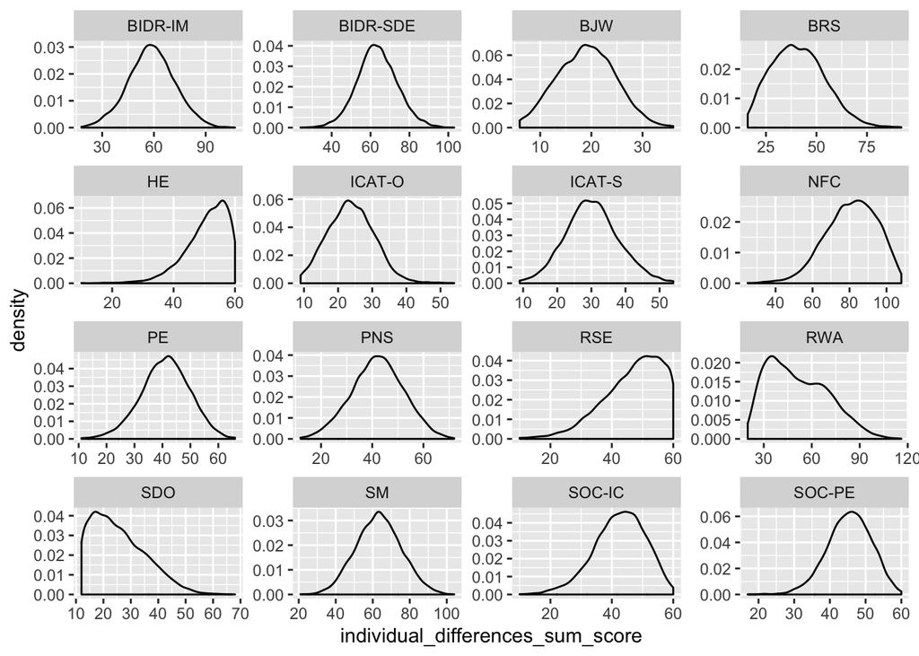

```r
# scales
trimmed_first_timepoint_per_user_per_scale %>%
  filter(!individual_differences_measure %in% c("BFI-Part 1",
                                                "BFI-Part 2",
                                                "NFCC, Part 1",
                                                "NFCC, Part 2")) %>%
  ggplot() +
  geom_density(aes(individual_differences_sum_score)) +
  facet_wrap(~individual_differences_measure, scales = "free")
```

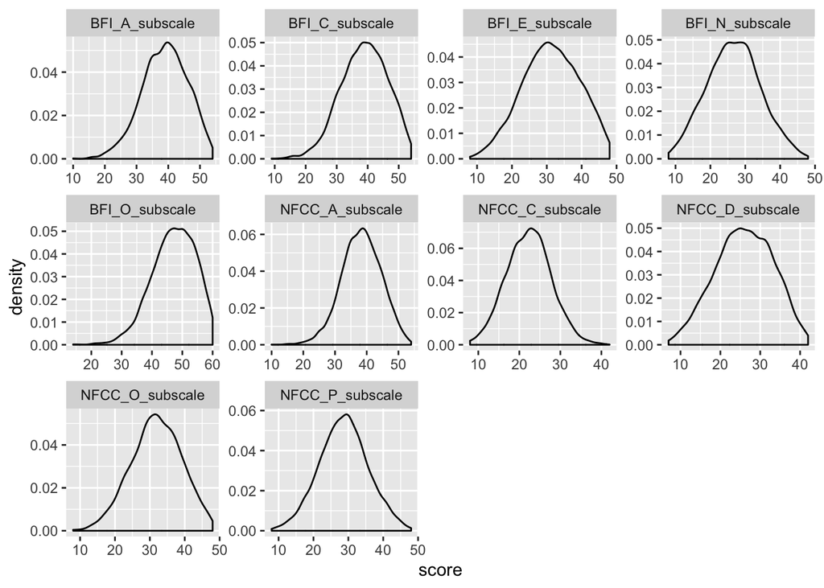

```r
# subscales where applicable
trimmed_first_timepoint_per_user_per_scale %>%
  select(session_id,
         BFI_E_subscale, BFI_C_subscale, BFI_N_subscale, BFI_A_subscale, BFI_O_subscale,
         NFCC_P_subscale, NFCC_D_subscale, NFCC_C_subscale, NFCC_O_subscale, NFCC_A_subscale) %>%
  gather(key = subscale, value = score, c(BFI_E_subscale, BFI_C_subscale, BFI_N_subscale, BFI_A_subscale, BFI_O_subscale,
                                          NFCC_P_subscale, NFCC_D_subscale, NFCC_C_subscale,
                                          NFCC_O_subscale, NFCC_A_subscale)) %>%
  na.omit() %>%
  ggplot() +
  geom_density(aes(score)) +
  facet_wrap(~subscale, scales = "free")
```

```r
## distribution info
distributions_auto <- function(data, scale_name) {
  require(moments)
  require(plotrix)
  data %>%
    mutate(sum = rowSums(.)) %>%
    dplyr::select(sum) %>%
    summarize(M = round(mean(sum, na.rm = TRUE), 2),
              SE = round(std.error(sum, na.rm = TRUE), 2),
              SD = round(sd(sum, na.rm = TRUE), 2),
              Skewness = round(skewness(sum), 2),
              Kurtosis = round(kurtosis(sum), 2)) %>%
    mutate(Scale = scale_name)
}

bfi_e_dist    <- bfi_e_data    %>% dplyr::select(-age, -sex) %>% distributions_auto(., scale_name = "Big 5 Inventory - E")
bfi_c_dist    <- bfi_c_data    %>% dplyr::select(-age, -sex) %>% distributions_auto(., scale_name = "Big 5 Inventory - C")
bfi_n_dist    <- bfi_n_data    %>% dplyr::select(-age, -sex) %>% distributions_auto(., scale_name = "Big 5 Inventory - N")
bfi_a_dist    <- bfi_a_data    %>% dplyr::select(-age, -sex) %>% distributions_auto(., scale_name = "Big 5 Inventory - A")
bfi_o_dist    <- bfi_o_data    %>% dplyr::select(-age, -sex) %>% distributions_auto(., scale_name = "Big 5 Inventory - O")
bidr_im_dist  <- bidr_im_data  %>% dplyr::select(-age, -sex) %>% distributions_auto(., scale_name = "Balanced Inventory of Desirable Responding - Impression Management")
bidr_sde_dist <- bidr_sde_data %>% dplyr::select(-age, -sex) %>% distributions_auto(., scale_name = "Balanced Inventory of Desirable Responding - Self Deception")
bjw_dist      <- bjw_data      %>% dplyr::select(-age, -sex) %>% distributions_auto(., scale_name = "Belief in a Just World: General Just World Scale")
brs_dist      <- brs_data      %>% dplyr::select(-age, -sex) %>% distributions_auto(., scale_name = "Bayesian Racism")
he_dist       <- he_data       %>% dplyr::select(-age, -sex) %>% distributions_auto(., scale_name = "Humanitarianism-Egalitarianism")
icat_o_dist   <- icat_o_data   %>% dplyr::select(-age, -sex) %>% distributions_auto(., scale_name = "Intuitions about Controllability and Awareness of Thoughts - Others")
icat_s_dist   <- icat_s_data   %>% dplyr::select(-age, -sex) %>% distributions_auto(., scale_name = "Intuitions about Controllability and Awareness of Thoughts - Self")
nfc_dist      <- nfc_data      %>% dplyr::select(-age, -sex) %>% distributions_auto(., scale_name = "Need for Cognition")
nfcc_a_dist   <- nfcc_a_data   %>% dplyr::select(-age, -sex) %>% distributions_auto(., scale_name = "Need for Cognitive Closure - A")
nfcc_o_dist   <- nfcc_o_data   %>% dplyr::select(-age, -sex) %>% distributions_auto(., scale_name = "Need for Cognitive Closure - O")
nfcc_p_dist   <- nfcc_p_data   %>% dplyr::select(-age, -sex) %>% distributions_auto(., scale_name = "Need for Cognitive Closure - P")
nfcc_d_dist   <- nfcc_d_data   %>% dplyr::select(-age, -sex) %>% distributions_auto(., scale_name = "Need for Cognitive Closure - D")
nfcc_c_dist   <- nfcc_c_data   %>% dplyr::select(-age, -sex) %>% distributions_auto(., scale_name = "Need for Cognitive Closure - C")
pe_dist       <- pe_data       %>% dplyr::select(-age, -sex) %>% distributions_auto(., scale_name = "Protestant Ethic")
pns_dist      <- pns_data      %>% dplyr::select(-age, -sex) %>% distributions_auto(., scale_name = "Personal Need for Structure")
rse_dist      <- rse_data      %>% dplyr::select(-age, -sex) %>% distributions_auto(., scale_name = "Rosenberg Self-Esteem")
rwa_dist      <- rwa_data      %>% dplyr::select(-age, -sex) %>% distributions_auto(., scale_name = "Ring-Wing Authoritarianism")
sdo_dist      <- sdo_data      %>% dplyr::select(-age, -sex) %>% distributions_auto(., scale_name = "Social Dominance Orientation")
sm_dist       <- sm_data       %>% dplyr::select(-age, -sex) %>% distributions_auto(., scale_name = "Self-Monitoring")
soc_ic_dist   <- soc_ic_data   %>% dplyr::select(-age, -sex) %>% distributions_auto(., scale_name = "Spheres of Control - Interpersonal Control")
soc_pe_dist   <- soc_pe_data   %>% dplyr::select(-age, -sex) %>% distributions_auto(., scale_name = "Spheres of Control - Personal Efficacy")

dist_results <- rbind(bfi_e_dist, bfi_c_dist, bfi_n_dist, bfi_a_dist, bfi_o_dist,
                      bidr_im_dist, bidr_sde_dist, bjw_dist, brs_dist,
                      he_dist, icat_o_dist, icat_s_dist, nfc_dist,
                      nfcc_a_dist, nfcc_o_dist, nfcc_p_dist, nfcc_d_dist, nfcc_c_dist,
                      pe_dist, pns_dist, rse_dist, rwa_dist, sdo_dist, sm_dist, soc_ic_dist, soc_pe_dist)

# remove redundant objects to keep the environment tidy
rm(bfi_e_dist, bfi_c_dist, bfi_n_dist, bfi_a_dist, bfi_o_dist,
   bidr_im_dist, bidr_sde_dist, bjw_dist, brs_dist,
   he_dist, icat_o_dist, icat_s_dist, nfc_dist,
   nfcc_a_dist, nfcc_o_dist, nfcc_p_dist, nfcc_d_dist, nfcc_c_dist,
   pe_dist, pns_dist, rse_dist, rwa_dist, sdo_dist, sm_dist, soc_ic_dist, soc_pe_dist)
```

## Internal consistency

```r
# needed for both consistency and cfa analyses
fit_cfa <- function(data, model) {
  require(lavaan)
  require(tidyverse)

  data %>%
    dplyr::select(-sex, -age) %>%
    cfa(model,
        data = .,
        order = c("1", "2", "3", "4", "5", "6"),
        estimator = "WLSMV")  # can notionally change this to Maximum Likelihood (ML) but produces worse fits across measures
}
```

```r
# check if these scores have already been computed and saved to disk. If so, load them. If not, compute them.
# this is done because the execution time for these is long - in the case of A scores it can be several hours.
if (exists(load("results/consistency_results.RData"))) {

  load("results/consistency_results.RData")

} else {


  n_boots <- 1000

  # NB the below code isn't as elegant as I'd like, but works just fine. `model` should be passed as an argument among the three nested functions, but I couldn't work out how to get purrr::map() to take an argument for the function it applies to the bootstraps. Instead, model is defined as a global variable before each estimate_reliability() call. This variable scoping is fine statistically, but represents suboptimal coding afaik.

  # helper function
  bootstrap_reliability_helper <- function(split, ...) {

    require(lavaan)
    require(semTools)
    require(tidyverse)

    fit_cfa(analysis(split), model) %>%
      reliability() %>%
      as.data.frame() %>%
      rownames_to_column(var = "metric") %>%
      select(metric, total) %>%
      filter(metric %in% c("alpha",
                           "omega2",
                           "omega3")) %>%
      mutate(metric = recode(metric,
                             "alpha" = "alpha",
                             "omega2" = "omega_t",
                             "omega3" = "omega_h"))

  }

  # apply bootstrapping, then extract coefficients via percentile method
  estimate_reliability <- function(data, scale, ...) {

    require(purrr)
    require(rsample)
    require(tidyverse)
    require(timesavers)

    # create bootstraps using out of bag method. makes a df with values that are collapsed dfs.
    boot_samples <- data %>%
      bootstraps(., times = n_boots)

    # apply to each bootstrap
    boots <- boot_samples %>%
      mutate(reliability_results = map(splits, bootstrap_reliability_helper)) %>%
      unnest(reliability_results)

    # find CIs using percentile method
    boot_estimates <- boots %>%
      group_by(metric) %>%
      summarize(median   = quantile(total, 0.500),
                ci_lower = quantile(total, 0.025),
                ci_upper = quantile(total, 0.975)) %>%
      round_df(3) %>%
      mutate(Scale = scale)

    return(boot_estimates)
  }

  model <- bfi_e_model
  consistency_bfi_e    <- estimate_reliability(bfi_e_data,    "Big 5 Inventory - E")

  model <- bfi_c_model
  consistency_bfi_c    <- estimate_reliability(bfi_c_data,    "Big 5 Inventory - C")

  model <- bfi_n_model
  consistency_bfi_n    <- estimate_reliability(bfi_n_data,    "Big 5 Inventory - N")

  model <- bfi_a_model
  consistency_bfi_a    <- estimate_reliability(bfi_a_data,    "Big 5 Inventory - A")

  model <- bfi_o_model
  consistency_bfi_o    <- estimate_reliability(bfi_o_data,    "Big 5 Inventory - O")

  model <- bidr_im_model
  consistency_bidr_im  <- estimate_reliability(bidr_im_data,  "Balanced Inventory of Desirable Responding - Impression Management")

  model <- bidr_sde_model
  consistency_bidr_sde <- estimate_reliability(bidr_sde_data, "Balanced Inventory of Desirable Responding - Self Deception")

  model <- bjw_model
  consistency_bjw      <- estimate_reliability(bjw_data,      "Belief in a Just World: General Just World Scale")

  model <- brs_model
  consistency_brs      <- estimate_reliability(brs_data,      "Bayesian Racism")

  model <- he_model
  consistency_he       <- estimate_reliability(he_data,       "Humanitarianism-Egalitarianism")

  model <- icat_o_model
  consistency_icat_o   <- estimate_reliability(icat_o_data,   "Intuitions about Controllability and Awareness of Thoughts - Others")

  model <- icat_s_model
  consistency_icat_s   <- estimate_reliability(icat_s_data,   "Intuitions about Controllability and Awareness of Thoughts - Self")

  model <- nfc_model
  consistency_nfc      <- estimate_reliability(nfc_data,      "Need for Cognition")

  model <- nfcc_a_model
  consistency_nfcc_a   <- estimate_reliability(nfcc_a_data,   "Need for Cognitive Closure - A")

  model <- nfcc_o_model
  consistency_nfcc_o   <- estimate_reliability(nfcc_o_data,   "Need for Cognitive Closure - O")

  model <- nfcc_p_model
  consistency_nfcc_p   <- estimate_reliability(nfcc_p_data,   "Need for Cognitive Closure - P")

  model <- nfcc_d_model
  consistency_nfcc_d   <- estimate_reliability(nfcc_d_data,   "Need for Cognitive Closure - D")

  model <- nfcc_c_model
  consistency_nfcc_c   <- estimate_reliability(nfcc_c_data,   "Need for Cognitive Closure - C")

  model <- pe_model
  consistency_pe       <- estimate_reliability(pe_data,       "Protestant Ethic")

  model <- pns_model
  consistency_pns      <- estimate_reliability(pns_data,      "Personal Need for Structure")

  model <- rse_model
  consistency_rse      <- estimate_reliability(rse_data,      "Rosenberg Self-Esteem")

  model <- rwa_model
  consistency_rwa      <- estimate_reliability(rwa_data,      "Ring-Wing Authoritarianism")

  model <- sdo_model
  consistency_sdo      <- estimate_reliability(sdo_data,      "Social Dominance Orientation")

  model <- sm_model
  consistency_sm       <- estimate_reliability(sm_data,       "Self-Monitoring")

  model <- soc_ic_model
  consistency_soc_ic   <- estimate_reliability(soc_ic_data,   "Spheres of Control - Interpersonal Control")

  model <- soc_pe_model
  consistency_soc_pe   <- estimate_reliability(soc_pe_data,   "Spheres of Control - Personal Efficacy")

  consistency_estimates_temp <- bind_rows(consistency_bfi_e,
                                          consistency_bfi_c,
                                          consistency_bfi_n,
                                          consistency_bfi_a,
                                          consistency_bfi_o,
                                          consistency_bidr_im,
                                          consistency_bidr_sde,
                                          consistency_bjw,
                                          consistency_brs,
                                          consistency_he,
                                          consistency_icat_o,
                                          consistency_icat_s,
                                          consistency_nfc,
                                          consistency_nfcc_a,
                                          consistency_nfcc_o,
                                          consistency_nfcc_p,
                                          consistency_nfcc_d,
                                          consistency_nfcc_c,
                                          consistency_pe,
                                          consistency_pns,
                                          consistency_rse,
                                          consistency_rwa,
                                          consistency_sdo,
                                          consistency_sm,
                                          consistency_soc_ic,
                                          consistency_soc_pe)

  consistency_estimates_alpha <- consistency_estimates_temp %>%
    filter(metric == "alpha") %>%
    select(-metric) %>%
    rename(alpha = median,
           alpha_ci_lower = ci_lower,
           alpha_ci_upper = ci_upper)

  consistency_estimates_omega_t <- consistency_estimates_temp %>%
    filter(metric == "omega_t") %>%
    select(-metric) %>%
    rename(omega_t = median,
           omega_t_ci_lower = ci_lower,
           omega_t_ci_upper = ci_upper)

  consistency_estimates_omega_h <- consistency_estimates_temp %>%
    filter(metric == "omega_h") %>%
    select(-metric) %>%
    rename(omega_h = median,
           omega_h_ci_lower = ci_lower,
           omega_h_ci_upper = ci_upper)

  consistency_results <- consistency_estimates_alpha %>%
    left_join(consistency_estimates_omega_t, by = "Scale") %>%
    left_join(consistency_estimates_omega_h, by = "Scale")

  # remove redundant objects to keep the environment tidy
  rm(consistency_estimates_alpha, consistency_estimates_omega_t, consistency_estimates_omega_h,
     consistency_bfi_e, consistency_bfi_c, consistency_bfi_n, consistency_bfi_a,
     consistency_bfi_o, consistency_bidr_im, consistency_bidr_sde, consistency_bjw, consistency_brs, consistency_he,
     consistency_icat_o, consistency_icat_s, consistency_nfc, consistency_nfcc_a, consistency_nfcc_o,
     consistency_nfcc_p, consistency_nfcc_d, consistency_nfcc_c, consistency_pe, consistency_pns,
     consistency_rse, consistency_rwa, consistency_sdo, consistency_sm, consistency_soc_ic, consistency_soc_pe)

  # save to disk
  save(consistency_results, file = "results/consistency_results.RData")
  #load("results/consistency_results.RData")

}
```

## Test-retest reliability

### Dependability

```r
dependability_data <- two_timepoint_scores %>%
  filter(days_to_followup < 1/24)  # retest within an hour

# total n
n_dependability <- nrow(dependability_data)

# # n per scale
n_per_scale_dependability <- dependability_data %>%
  count(individual_differences_measure) %>%
  rename(Scale = individual_differences_measure,
         `Test-retest dependability n` = n)

pearson_r_estimate <- function(data, Scale){
  require(tidyverse)
  require(psych)

  res <- data %>%
    filter(individual_differences_measure == Scale) %>%
    select(individual_differences_sum_score_t1, individual_differences_sum_score_t2) %>%
    cor.ci(n.iter = 1000, method = "pearson", plot = FALSE)

  results <-
    data.frame(Scale = Scale,
               pearson_r = res$means,
               pearson_r_ci_lwr = res$ci$low.e,
               pearson_r_ci_upr = res$ci$up.e) %>%
    round_df(3)

  return(results)
}

dependability_results <-
  rbind(pearson_r_estimate(data = dependability_data, Scale = "BFI_E"),
        pearson_r_estimate(data = dependability_data, Scale = "BFI_C"),
        pearson_r_estimate(data = dependability_data, Scale = "BFI_N"),
        pearson_r_estimate(data = dependability_data, Scale = "BFI_A"),
        pearson_r_estimate(data = dependability_data, Scale = "BFI_O"),
        pearson_r_estimate(data = dependability_data, Scale = "BIDR-IM"),
        pearson_r_estimate(data = dependability_data, Scale = "BIDR-SDE"),
        pearson_r_estimate(data = dependability_data, Scale = "BJW"),
        pearson_r_estimate(data = dependability_data, Scale = "BRS"),
        pearson_r_estimate(data = dependability_data, Scale = "HE"),
        pearson_r_estimate(data = dependability_data, Scale = "ICAT-O"),
        pearson_r_estimate(data = dependability_data, Scale = "ICAT-S"),
        pearson_r_estimate(data = dependability_data, Scale = "NFC"),
        pearson_r_estimate(data = dependability_data, Scale = "NFCC_A"),
        pearson_r_estimate(data = dependability_data, Scale = "NFCC_O"),
        pearson_r_estimate(data = dependability_data, Scale = "NFCC_P"),
        pearson_r_estimate(data = dependability_data, Scale = "NFCC_D"),
        pearson_r_estimate(data = dependability_data, Scale = "NFCC_C"),
        pearson_r_estimate(data = dependability_data, Scale = "PE"),
        pearson_r_estimate(data = dependability_data, Scale = "PNS"),
        pearson_r_estimate(data = dependability_data, Scale = "RSE"),
        pearson_r_estimate(data = dependability_data, Scale = "RWA"),
        pearson_r_estimate(data = dependability_data, Scale = "SDO"),
        pearson_r_estimate(data = dependability_data, Scale = "SM"),
        pearson_r_estimate(data = dependability_data, Scale = "SOC-IC"),
        pearson_r_estimate(data = dependability_data, Scale = "SOC-PE")) %>%
  rename(`Test-retest dependability r` = pearson_r,
         `dependability r lower` = pearson_r_ci_lwr,
         `dependability r upper` = pearson_r_ci_upr) %>%
  full_join(n_per_scale_dependability, by = "Scale") %>%
  mutate(Scale = dplyr::recode(Scale,
                               "BFI_E"    = "Big 5 Inventory - E",
                               "BFI_C"    = "Big 5 Inventory - C",
                               "BFI_N"    = "Big 5 Inventory - N",
                               "BFI_A"    = "Big 5 Inventory - A",
                               "BFI_O"    = "Big 5 Inventory - O",
                               "BIDR-IM"  = "Balanced Inventory of Desirable Responding - Impression Management",
                               "BIDR-SDE" = "Balanced Inventory of Desirable Responding - Self Deception",
                               "BJW"      = "Belief in a Just World: General Just World Scale",
                               "BRS"      = "Bayesian Racism",
                               "HE"       = "Humanitarianism-Egalitarianism",
                               "ICAT-O"   = "Intuitions about Controllability and Awareness of Thoughts - Others",
                               "ICAT-S"   = "Intuitions about Controllability and Awareness of Thoughts - Self",
                               "NFC"      = "Need for Cognition",
                               "NFCC_P"  = "Need for Cognitive Closure - P",
                               "NFCC_D"  = "Need for Cognitive Closure - D",
                               "NFCC_C"  = "Need for Cognitive Closure - C",
                               "NFCC_A"  = "Need for Cognitive Closure - A",
                               "NFCC_O"  = "Need for Cognitive Closure - O",
                               "PE"       = "Protestant Ethic",
                               "PNS"      = "Personal Need for Structure",
                               "RSE"      = "Rosenberg Self-Esteem",
                               "RWA"      = "Ring-Wing Authoritarianism",
                               "SDO"      = "Social Dominance Orientation",
                               "SM"       = "Self-Monitoring",
                               "SOC-IC"   = "Spheres of Control - Interpersonal Control",
                               "SOC-PE"   = "Spheres of Control - Personal Efficacy"))
```

total n dependability: 3812

### Stability

```r
stability_data <- two_timepoint_scores %>%
  filter(days_to_followup >= 1 & days_to_followup < 365)  # retest more than a day and less than a year later

# total n
n_stability <- nrow(stability_data)

# n per scale
n_per_scale_stability <- stability_data %>%
  count(individual_differences_measure) %>%
  rename(Scale = individual_differences_measure,
         `Test-retest stability n` = n)

stability_results <-
  rbind(pearson_r_estimate(data = stability_data, Scale = "BFI_E"),
        pearson_r_estimate(data = stability_data, Scale = "BFI_C"),
        pearson_r_estimate(data = stability_data, Scale = "BFI_N"),
        pearson_r_estimate(data = stability_data, Scale = "BFI_A"),
        pearson_r_estimate(data = stability_data, Scale = "BFI_O"),
        pearson_r_estimate(data = stability_data, Scale = "BIDR-IM"),
        pearson_r_estimate(data = stability_data, Scale = "BIDR-SDE"),
        pearson_r_estimate(data = stability_data, Scale = "BJW"),
        pearson_r_estimate(data = stability_data, Scale = "BRS"),
        pearson_r_estimate(data = stability_data, Scale = "HE"),
        pearson_r_estimate(data = stability_data, Scale = "ICAT-O"),
        pearson_r_estimate(data = stability_data, Scale = "ICAT-S"),
        pearson_r_estimate(data = stability_data, Scale = "NFC"),
        pearson_r_estimate(data = stability_data, Scale = "NFCC_A"),
        pearson_r_estimate(data = stability_data, Scale = "NFCC_O"),
        pearson_r_estimate(data = stability_data, Scale = "NFCC_P"),
        pearson_r_estimate(data = stability_data, Scale = "NFCC_D"),
        pearson_r_estimate(data = stability_data, Scale = "NFCC_C"),
        pearson_r_estimate(data = stability_data, Scale = "PE"),
        pearson_r_estimate(data = stability_data, Scale = "PNS"),
        pearson_r_estimate(data = stability_data, Scale = "RSE"),
        pearson_r_estimate(data = stability_data, Scale = "RWA"),
        pearson_r_estimate(data = stability_data, Scale = "SDO"),
        pearson_r_estimate(data = stability_data, Scale = "SM"),
        pearson_r_estimate(data = stability_data, Scale = "SOC-IC"),
        pearson_r_estimate(data = stability_data, Scale = "SOC-PE")) %>%
  rename(`Test-retest stability r` = pearson_r,
         `stability r lower` = pearson_r_ci_lwr,
         `stability r upper` = pearson_r_ci_upr) %>%
  full_join(n_per_scale_stability, by = "Scale") %>%
  mutate(Scale = dplyr::recode(Scale,
                               "BFI_E"    = "Big 5 Inventory - E",
                               "BFI_C"    = "Big 5 Inventory - C",
                               "BFI_N"    = "Big 5 Inventory - N",
                               "BFI_A"    = "Big 5 Inventory - A",
                               "BFI_O"    = "Big 5 Inventory - O",
                               "BIDR-IM"  = "Balanced Inventory of Desirable Responding - Impression Management",
                               "BIDR-SDE" = "Balanced Inventory of Desirable Responding - Self Deception",
                               "BJW"      = "Belief in a Just World: General Just World Scale",
                               "BRS"      = "Bayesian Racism",
                               "HE"       = "Humanitarianism-Egalitarianism",
                               "ICAT-O"   = "Intuitions about Controllability and Awareness of Thoughts - Others",
                               "ICAT-S"   = "Intuitions about Controllability and Awareness of Thoughts - Self",
                               "NFC"      = "Need for Cognition",
                               "NFCC_P"  = "Need for Cognitive Closure - P",
                               "NFCC_D"  = "Need for Cognitive Closure - D",
                               "NFCC_C"  = "Need for Cognitive Closure - C",
                               "NFCC_A"  = "Need for Cognitive Closure - A",
                               "NFCC_O"  = "Need for Cognitive Closure - O",
                               "PE"       = "Protestant Ethic",
                               "PNS"      = "Personal Need for Structure",
                               "RSE"      = "Rosenberg Self-Esteem",
                               "RWA"      = "Ring-Wing Authoritarianism",
                               "SDO"      = "Social Dominance Orientation",
                               "SM"       = "Self-Monitoring",
                               "SOC-IC"   = "Spheres of Control - Interpersonal Control",
                               "SOC-PE"   = "Spheres of Control - Personal Efficacy"))
```

total n stability: 3730

## CFA fits

```r
## fit a CFA and return its model fit statistics
cfa_fit_metrics <- function(fit, scale) {

  require(lavaan)
  require(tidyverse)

  # fit statistics
  fit_stats <- data.frame(estimate = fitMeasures(fit)) %>%
    rownames_to_column(var = "metric") %>%
    filter(metric %in% c("chisq", "df", "pvalue", "srmr", "rmsea", "rmsea.ci.lower", "rmsea.ci.upper", "cfi", "tli")) %>%
    spread(metric, estimate) %>%
    mutate(Scale = scale,
           pvalue = ifelse(pvalue < .0001, "< .0001", as.character(round(pvalue, 4))),
           "chisq/df"  = round(chisq/df, 1),
           cfa_test = ifelse(srmr <= .09 & cfi >= .95 & tli >= .95 & rmsea <= .06, "Good",
                                ifelse(srmr <= .09 & (cfi >= .95 | tli >= .95 | rmsea <= .06), "Mixed", "Poor")),
           cfa_test = fct_relevel(cfa_test, "Good", "Mixed", "Poor"))

  return(fit_stats)
}

cfi_fit_results <-
  bind_rows(cfa_fit_metrics(fit_cfa(bfi_e_data,    bfi_e_model),    scale = "Big 5 Inventory - E"),
            cfa_fit_metrics(fit_cfa(bfi_c_data,    bfi_c_model),    scale = "Big 5 Inventory - C"),
            cfa_fit_metrics(fit_cfa(bfi_n_data,    bfi_n_model),    scale = "Big 5 Inventory - N"),
            cfa_fit_metrics(fit_cfa(bfi_a_data,    bfi_a_model),    scale = "Big 5 Inventory - A"),
            cfa_fit_metrics(fit_cfa(bfi_o_data,    bfi_o_model),    scale = "Big 5 Inventory - O"),
            cfa_fit_metrics(fit_cfa(bidr_im_data,  bidr_im_model),  scale = "Balanced Inventory of Desirable Responding - Impression Management"),
            cfa_fit_metrics(fit_cfa(bidr_sde_data, bidr_sde_model), scale = "Balanced Inventory of Desirable Responding - Self Deception"),
            cfa_fit_metrics(fit_cfa(bjw_data,      bjw_model),      scale = "Belief in a Just World: General Just World Scale"),
            cfa_fit_metrics(fit_cfa(brs_data,      brs_model),      scale = "Bayesian Racism"),
            cfa_fit_metrics(fit_cfa(he_data,       he_model),       scale = "Humanitarianism-Egalitarianism"),
            cfa_fit_metrics(fit_cfa(icat_o_data,   icat_o_model),   scale = "Intuitions about Controllability and Awareness of Thoughts - Others"),
            cfa_fit_metrics(fit_cfa(icat_s_data,   icat_s_model),   scale = "Intuitions about Controllability and Awareness of Thoughts - Self"),
            cfa_fit_metrics(fit_cfa(nfc_data,      nfc_model),      scale = "Need for Cognition"),
            cfa_fit_metrics(fit_cfa(nfcc_a_data,   nfcc_a_model),   scale = "Need for Cognitive Closure - O"),
            cfa_fit_metrics(fit_cfa(nfcc_o_data,   nfcc_o_model),   scale = "Need for Cognitive Closure - A"),
            cfa_fit_metrics(fit_cfa(nfcc_p_data,   nfcc_p_model),   scale = "Need for Cognitive Closure - P"),
            cfa_fit_metrics(fit_cfa(nfcc_d_data,   nfcc_d_model),   scale = "Need for Cognitive Closure - D"),
            cfa_fit_metrics(fit_cfa(nfcc_c_data,   nfcc_c_model),   scale = "Need for Cognitive Closure - C"),
            cfa_fit_metrics(fit_cfa(pe_data,       pe_model),       scale = "Protestant Ethic"),
            cfa_fit_metrics(fit_cfa(pns_data,      pns_model),      scale = "Personal Need for Structure"),
            cfa_fit_metrics(fit_cfa(rse_data,      rse_model),      scale = "Rosenberg Self-Esteem"),
            cfa_fit_metrics(fit_cfa(rwa_data,      rwa_model),      scale = "Ring-Wing Authoritarianism"),
            cfa_fit_metrics(fit_cfa(sdo_data,      sdo_model),      scale = "Social Dominance Orientation"),
            cfa_fit_metrics(fit_cfa(sm_data,       sm_model),       scale = "Self-Monitoring"),
            cfa_fit_metrics(fit_cfa(soc_ic_data,   soc_ic_model),   scale = "Spheres of Control - Interpersonal Control"),
            cfa_fit_metrics(fit_cfa(soc_pe_data,   soc_pe_model),   scale = "Spheres of Control - Personal Efficacy")) %>%
  round_df(3)
```

## Measurement Invariance

Between groups: gender and median age.

# Results

## Combined table of results

```r
combined_results <- n_per_scale %>%
  left_join(cfi_fit_results, by = "Scale") %>%
  left_join(dist_results,          by = "Scale") %>%
  left_join(consistency_results,   by = "Scale") %>%
  left_join(dependability_results, by = "Scale") %>%
  left_join(stability_results,     by = "Scale") %>%
  left_join(MI_results,            by = "Scale") %>%
  left_join(additional_scale_data, by = "Scale") %>%

  # apply cutoffs to reliability metrics
  dplyr::mutate(alpha_test   = ifelse(alpha >= .7,   "Passed", "Failed"),
                omega_t_test = ifelse(omega_t >= .7, "Passed", "Failed"),
                omega_h_test = ifelse(omega_h >= .7, "Passed", "Failed"),
                dependability_test = ifelse("Test-retest dependability r" >= .7, "Passed", "Failed"),
                stability_test     = ifelse("Test-retest stability r" >= .7,     "Passed", "Failed"),
                test_retest_test = ifelse(dependability_test == "Passed" & stability_test == "Passed", "Passed",
                                          ifelse(dependability_test == "Failed" & stability_test == "Failed", "Failed", NA)),
                overall_scale_test = ifelse(omega_t >= .7 &
                                              ("Test-retest dependability r" >= .7 |
                                                 is.na(`Test-retest dependability r`)) &
                                              ("Test-retest stability r" >= .7 |
                                                 is.na(`Test-retest stability r`)) &
                                              (cfa_test == "Good" | cfa_test == "Mixed") &
                                              MI_test == "Passed", "Good", "Questionable")) %>%
  # reorder columns
  dplyr::select(Scale, n, Items,
                M, SD, Skewness, Kurtosis,
                # internal consistency
                alpha, alpha_ci_lower, alpha_ci_upper, alpha_test,
                omega_t, omega_t_ci_lower, omega_t_ci_upper, omega_t_test,
                omega_h, omega_h_ci_lower, omega_h_ci_upper, omega_h_test,
                # test-retest reliability
                "Test-retest dependability n", "Test-retest dependability r",
                "dependability r lower", "dependability r upper", dependability_test,
                "Test-retest stability n", "Test-retest stability r",
                "stability r lower", "stability r upper", stability_test, test_retest_test,
                # cfa fit
                chisq, "chisq/df", df, pvalue,
                cfi, tli, rmsea, rmsea.ci.lower, rmsea.ci.upper, srmr, cfa_test,
                # measurement invariance
                MI_age, MI_age_test_failed, MI_sex, MI_sex_test_failed, MI_test,
                # summary
                overall_scale_test,
                # details
                Changes, Interpretation) %>%
  arrange(Scale)

# write to disk
write_csv(combined_results, "results/main_results_table.csv", na = "")
```

## Summary table

```r
# convert string conclusions to binary pass/fail
binarized_combined_results <- combined_results %>%
  mutate(alpha_test         = ifelse(alpha_test == "Passed", 1,
                                     ifelse(alpha_test == "Failed", 0, NA)),
         test_retest_test   = ifelse(test_retest_test == "Passed", 1,
                                     ifelse(test_retest_test == "Failed", 0, NA)),
         cfa_test           = ifelse(cfa_test == "Mixed" | cfa_test == "Good", 1,
                                     ifelse(cfa_test == "Poor", 0, NA)),
         MI_test            = ifelse(MI_test == "Passed", 1,
                                     ifelse(MI_test == "Failed", 0, NA)),
         overall_scale_test = ifelse(overall_scale_test == "Good", 1,
                                     ifelse(overall_scale_test == "Questionable", 0, NA))) %>%
  select(Scale,
         alpha_test,
         test_retest_test,
         cfa_test,
         MI_test,
         overall_scale_test)

# summarize across scales
summarized_combined_results <- binarized_combined_results %>%
  gather(key, value, -Scale) %>%
  group_by(key) %>%
  summarize(percent = as.character(round(mean(value, na.rm = TRUE)*100, 0))) %>%
  spread(key, percent) %>%
  mutate(Scale = "Summary")

# create table of summarized results
summary_table <- combined_results %>%
  bind_rows(summarized_combined_results) %>%
  rename("Internal consistency" = alpha_test,
         "Test-retest reliability" = test_retest_test,
         "Confirmatory factor structure" = cfa_test,
         "Measurement invariance" = MI_test,
         "Global structural validity" = overall_scale_test) %>%
  select(Scale,
         "Internal consistency",
         "Test-retest reliability",
         "Confirmatory factor structure",
         "Measurement invariance",
         "Global structural validity")

write_csv(summary_table, "results/main_results_summary.csv", na = "")

summary_table %>%
  kable() %>%
  kable_styling(bootstrap_options = c("striped", "hover", "condensed"), full_width = FALSE)
```

| Scale | Internal consistency | Test-retest reliability | Confirmatory factor structure | Measurement invariance | Global structural validity |
| --- | --- | --- | --- | --- | --- |
| Balanced Inventory of Desirable Responding - Impression Management | Passed | Passed | Mixed | NA | NA |
| Balanced Inventory of Desirable Responding - Self Deception | Passed | Passed | Poor | Failed | Questionable |
| Bayesian Racism | Passed | Passed | Good | Failed | Questionable |
| Belief in a Just World: General Just World Scale | Passed | Passed | Good | NA | NA |
| Big 5 Inventory - A | Passed | Passed | Mixed | Failed | Questionable |
| Big 5 Inventory - C | Passed | Passed | Good | Failed | Questionable |
| Big 5 Inventory - E | Passed | Passed | Mixed | Failed | Questionable |
| Big 5 Inventory - N | Passed | Passed | Mixed | Failed | Questionable |
| Big 5 Inventory - O | Passed | Passed | Poor | Failed | Questionable |
| Humanitarianism-Egalitarianism | Passed | Passed | Good | Failed | Questionable |
| Intuitions about Controllability and Awareness of Thoughts - Others | Passed | Passed | Poor | Failed | Questionable |
| Intuitions about Controllability and Awareness of Thoughts - Self | Passed | Passed | Poor | Failed | Questionable |
| Need for Cognition | Passed | Passed | Good | NA | NA |
| Need for Cognitive Closure - A | Failed | Passed | Good | NA | Questionable |
| Need for Cognitive Closure - C | Failed | Passed | Mixed | Failed | Questionable |
| Need for Cognitive Closure - D | Passed | Passed | Good | Failed | Questionable |
| Need for Cognitive Closure - O | Passed | Passed | Good | Failed | Questionable |
| Need for Cognitive Closure - P | Passed | Passed | Good | Failed | Questionable |
| Personal Need for Structure | Passed | Passed | Mixed | Failed | Questionable |
| Protestant Ethic | Passed | Passed | Mixed | Failed | Questionable |
| Ring-Wing Authoritarianism | Passed | Passed | Mixed | Failed | Questionable |
| Rosenberg Self-Esteem | Passed | Passed | Good | Failed | Questionable |
| Self-Monitoring | Passed | Passed | Poor | Failed | Questionable |
| Social Dominance Orientation | Passed | Passed | Poor | Failed | Questionable |
| Spheres of Control - Interpersonal Control | Passed | Passed | Good | Failed | Questionable |
| Spheres of Control - Personal Efficacy | Failed | Passed | Poor | Failed | Questionable |
| Summary | 88 | 100 | 73 | 0 | 0 |

## Alluvial plot

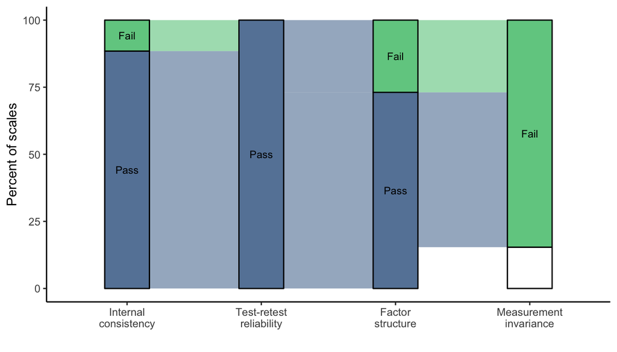

```r
# subset
n_scales <- nrow(binarized_combined_results)

data_alluvial_plot <- binarized_combined_results %>%
  dplyr::count(alpha_test, test_retest_test, cfa_test, MI_test) %>%
  rownames_to_column() %>%
  tidyr::gather(key = "metric",
                value = "validity",
                -c(rowname, n)) %>%
  mutate(validity = ifelse(is.na(validity), 2, validity),
         validity = dplyr::recode(validity,
                                  `0` = "Fail",
                                  `1` = "Pass"),
         validity = forcats::fct_relevel(as.factor(validity),
                                         "Fail", "Pass"),
         metric = dplyr::recode(as.character(metric),
                                "alpha_test" = "Internal\nconsistency",
                                "test_retest_test" = "Test-retest\nreliability",
                                "cfa_test" = "Factor\nstructure",
                                "MI_test" = "Measurement\ninvariance"),
         metric = forcats::fct_relevel(as.factor(metric),
                                       "Internal\nconsistency",
                                       "Test-retest\nreliability",
                                       "Factor\nstructure",
                                       "Measurement\ninvariance"),
         n = n/n_scales*100)

# alluvial plot with flow
p_figure_1 <-
  ggplot(data_alluvial_plot,
       aes(x = metric,
           stratum = validity,
           alluvium = rowname,
           y = n,
           fill = validity,
           label = validity)) +
  geom_flow(alpha = .5) +
  geom_stratum(alpha = .8) +
  theme_classic() +
  geom_text(stat = "stratum", size = 3) + # , angle = 90
  theme(legend.position = "none") +
  ylab("Percent of scales") +
  xlab("") +
  scale_fill_viridis_d(option = "viridis", direction = -1, begin = 0.3, end = 0.7)

p_figure_1
```

# Effect sizes for CFA and MI (mis)fit

A reviewer asked that we include a continuous effect size metric to quantify the impact of measurement (in)variance. We elected to also include metrics for the CFA models.

## Correlations between latent and observed scores, and misclassification rate between them

i.e., effect sizes for CFA (mis)fit.

Magnitue of the correlations between latent scores and observed sum scores represent the (in)congruence between them. However, it is easy to misinterpret these correlations as representing near perfect just because they are “high” by the standards of bivariate relations (e.g., r >.95). In order to illustrate the impact of of such latent-observed incongruenties, we also dichotomize participants into groups based on mean latent/observed sum scores*, and assess the rate of incongruent classifications (e.g., participants assigned to the high group on the latent scale but low group on the observed or vice versa). These illustrate that even “high” correlations such as *r* = .95 give rise to suprisingly high rates of incongruent classifications, which have many implications for the use of these scales.

*Of course, cut points for dichotomization are a subject of debate. Simply for illustrative purposes, we use the mean of the scale (i.e., 0 on the scaled and centered variable) to show the rate of incongruent conclusions when using the observed sum score vs. the latent mean for decision making.

```r
# fit models
bfi_e_fit    <- fit_cfa(data = bfi_e_data,    model = bfi_e_model)
bfi_c_fit    <- fit_cfa(data = bfi_c_data,    model = bfi_c_model)
bfi_n_fit    <- fit_cfa(data = bfi_n_data,    model = bfi_n_model)
bfi_a_fit    <- fit_cfa(data = bfi_a_data,    model = bfi_a_model)
bfi_o_fit    <- fit_cfa(data = bfi_o_data,    model = bfi_o_model)
bidr_im_fit  <- fit_cfa(data = bidr_im_data,  model = bidr_im_model)
bidr_sde_fit <- fit_cfa(data = bidr_sde_data, model = bidr_sde_model)
bjw_fit      <- fit_cfa(data = bjw_data,      model = bjw_model)
brs_fit      <- fit_cfa(data = brs_data,      model = brs_model)
he_fit       <- fit_cfa(data = he_data,       model = he_model)
icat_o_fit   <- fit_cfa(data = icat_o_data,   model = icat_o_model)
icat_s_fit   <- fit_cfa(data = icat_s_data,   model = icat_s_model)
nfc_fit      <- fit_cfa(data = nfc_data,      model = nfc_model)
nfcc_p_fit   <- fit_cfa(data = nfcc_p_data,   model = nfcc_p_model)
nfcc_d_fit   <- fit_cfa(data = nfcc_d_data,   model = nfcc_d_model)
nfcc_c_fit   <- fit_cfa(data = nfcc_c_data,   model = nfcc_c_model)
nfcc_a_fit   <- fit_cfa(data = nfcc_a_data,   model = nfcc_a_model)
nfcc_o_fit   <- fit_cfa(data = nfcc_o_data,   model = nfcc_o_model)
pe_fit       <- fit_cfa(data = pe_data,       model = pe_model)
pns_fit      <- fit_cfa(data = pns_data,      model = pns_model)
rse_fit      <- fit_cfa(data = rse_data,      model = rse_model)
rwa_fit      <- fit_cfa(data = rwa_data,      model = rwa_model)
sdo_fit      <- fit_cfa(data = sdo_data,      model = sdo_model)
sm_fit       <- fit_cfa(data = sm_data,       model = sm_model)
soc_ic_fit   <- fit_cfa(data = soc_ic_data,   model = soc_ic_model)
soc_pe_fit   <- fit_cfa(data = soc_pe_data,   model = soc_pe_model)


# calculate latent and observed sum scores
latent_observed_bfi_e <- bfi_e_data %>%
  mutate(latent = as.data.frame(lavPredict(bfi_e_fit))$E) %>%
  rowwise() %>%
  mutate(observed = mean(c(bfi_e1, bfi_e2, bfi_e3, bfi_e4, bfi_e5, bfi_e6, bfi_e7, bfi_e8))) %>%
  ungroup() %>%
  select(age, sex,
         latent, observed)

latent_observed_bfi_c <- bfi_c_data %>%
  mutate(latent = as.data.frame(lavPredict(bfi_c_fit))$C) %>%
  rowwise() %>%
  mutate(observed = mean(c(bfi_c1, bfi_c2, bfi_c3, bfi_c4, bfi_c5, bfi_c6, bfi_c7, bfi_c8, bfi_c9))) %>%
  ungroup() %>%
  select(age, sex,
         latent, observed)

latent_observed_bfi_n <- bfi_n_data %>%
  mutate(latent = as.data.frame(lavPredict(bfi_n_fit))$N) %>%
  rowwise() %>%
  mutate(observed = mean(c(bfi_n1, bfi_n2, bfi_n3, bfi_n4, bfi_n5, bfi_n6, bfi_n7, bfi_n8))) %>%
  ungroup() %>%
  select(age, sex,
         latent, observed)

latent_observed_bfi_a <- bfi_a_data %>%
  mutate(latent = as.data.frame(lavPredict(bfi_a_fit))$A) %>%
  rowwise() %>%
  mutate(observed = mean(c(bfi_a1, bfi_a2, bfi_a3, bfi_a4, bfi_a5, bfi_a6, bfi_a7, bfi_a8, bfi_a9))) %>%
  ungroup() %>%
  select(age, sex,
         latent, observed)

latent_observed_bfi_o <- bfi_o_data %>%
  mutate(latent = as.data.frame(lavPredict(bfi_o_fit))$O) %>%
  rowwise() %>%
  mutate(observed = mean(c(bfi_o1, bfi_o2, bfi_o3, bfi_o4, bfi_o5, bfi_o6, bfi_o7, bfi_o8, bfi_o9, bfi_o10))) %>%
  ungroup() %>%
  select(age, sex,
         latent, observed)

latent_observed_bidr_im <- bidr_im_data %>%
  mutate(latent = as.data.frame(lavPredict(bidr_im_fit))$IM) %>%
  rowwise() %>%
  mutate(observed = mean(c(bidr_im1, bidr_im2, bidr_im3, bidr_im4, bidr_im5, bidr_im6, bidr_im7, bidr_im8, bidr_im9, bidr_im10, bidr_im11, bidr_im12, bidr_im13, bidr_im14, bidr_im15, bidr_im16, bidr_im17, bidr_im18))) %>%
  ungroup() %>%
  select(age, sex,
         latent, observed)

latent_observed_bidr_sde <- bidr_sde_data %>%
  mutate(latent = as.data.frame(lavPredict(bidr_sde_fit))$SDE) %>%
  rowwise() %>%
  mutate(observed = mean(c(bidr_sde1, bidr_sde2, bidr_sde3, bidr_sde4, bidr_sde5, bidr_sde6, bidr_sde7, bidr_sde8, bidr_sde9, bidr_sde10, bidr_sde11, bidr_sde12, bidr_sde13, bidr_sde14, bidr_sde15, bidr_sde16, bidr_sde17, bidr_sde18))) %>%
  ungroup() %>%
  select(age, sex,
         latent, observed)

latent_observed_bjw <- bjw_data %>%
  mutate(latent = as.data.frame(lavPredict(bjw_fit))$BJW) %>%
  rowwise() %>%
  mutate(observed = mean(c(bjw1, bjw2, bjw3, bjw4, bjw5, bjw6))) %>%
  ungroup() %>%
  select(age, sex,
         latent, observed)

latent_observed_brs <- brs_data %>%
  mutate(latent = as.data.frame(lavPredict(brs_fit))$BRS) %>%
  rowwise() %>%
  mutate(observed = mean(c(brs1, brs2, brs3, brs4, brs5, brs6, brs7, brs8, brs9, brs10, brs11, brs12, brs13, brs14, brs15, brs16))) %>%
  ungroup() %>%
  select(age, sex,
         latent, observed)

latent_observed_he <- he_data %>%
  mutate(latent = as.data.frame(lavPredict(he_fit))$HE) %>%
  rowwise() %>%
  mutate(observed = mean(c(he1, he2, he3, he4, he5, he6, he7, he8, he9, he10))) %>%
  ungroup() %>%
  select(age, sex,
         latent, observed)

latent_observed_icat_o <- icat_o_data %>%
  mutate(latent = as.data.frame(lavPredict(icat_o_fit))$ICAT_O) %>%
  rowwise() %>%
  mutate(observed = mean(c(icat_o1, icat_o2, icat_o3, icat_o4, icat_o5, icat_o6, icat_o7, icat_o8, icat_o9))) %>%
  ungroup() %>%
  select(age, sex,
         latent, observed)

latent_observed_icat_s <- icat_s_data %>%
  mutate(latent = as.data.frame(lavPredict(icat_s_fit))$ICAT_S) %>%
  rowwise() %>%
  mutate(observed = mean(c(icat_s1, icat_s2, icat_s3, icat_s4, icat_s5, icat_s6, icat_s7, icat_s8, icat_s9))) %>%
  ungroup() %>%
  select(age, sex,
         latent, observed)

latent_observed_nfc <- nfc_data %>%
  mutate(latent = as.data.frame(lavPredict(nfc_fit))$NFC) %>%
  rowwise() %>%
  mutate(observed = mean(c(nfc1, nfc2, nfc3, nfc4, nfc5, nfc6, nfc7, nfc8, nfc9, nfc10, nfc11, nfc12, nfc13, nfc14, nfc15, nfc16, nfc17, nfc18))) %>%
  ungroup() %>%
  select(age, sex,
         latent, observed)

latent_observed_nfcc_p <- nfcc_p_data %>%
  mutate(latent = as.data.frame(lavPredict(nfcc_p_fit))$P) %>%
  rowwise() %>%
  mutate(observed = mean(c(nfcc_p1, nfcc_p2, nfcc_p3, nfcc_p4, nfcc_p5, nfcc_p6, nfcc_p7, nfcc_p8))) %>%
  ungroup() %>%
  select(age, sex,
         latent, observed)
```

```r
latent_observed_nfcc_d <- nfcc_d_data %>%
  mutate(latent = as.data.frame(lavPredict(nfcc_d_fit))$D) %>%
  rowwise() %>%
  mutate(observed = mean(c(nfcc_d1, nfcc_d2, nfcc_d3, nfcc_d4, nfcc_d5, nfcc_d6, nfcc_d7))) %>%
  ungroup() %>%
  select(age, sex,
         latent, observed)

latent_observed_nfcc_c <- nfcc_c_data %>%
  mutate(latent = as.data.frame(lavPredict(nfcc_c_fit))$C) %>%
  rowwise() %>%
  mutate(observed = mean(c(nfcc_c1, nfcc_c2, nfcc_c3, nfcc_c4, nfcc_c5, nfcc_c6, nfcc_c7, nfcc_c8))) %>%
  ungroup() %>%
  select(age, sex, latent, observed)

latent_observed_nfcc_a <- nfcc_a_data %>%
  mutate(latent = as.data.frame(lavPredict(nfcc_a_fit))$A) %>%
  rowwise() %>%
  mutate(observed = mean(c(nfcc_a1, nfcc_a2, nfcc_a3, nfcc_a4, nfcc_a5, nfcc_a6, nfcc_a7, nfcc_a8))) %>%
  ungroup() %>%
  select(age, sex,
         latent, observed)

latent_observed_nfcc_o <- nfcc_o_data %>%
  mutate(latent = as.data.frame(lavPredict(nfcc_o_fit))$O) %>%
  rowwise() %>%
  mutate(observed = mean(c(nfcc_o1, nfcc_o2, nfcc_o3, nfcc_o4, nfcc_o5, nfcc_o6, nfcc_o7))) %>%
  ungroup() %>%
  select(age, sex,
         latent, observed)

latent_observed_pe <- pe_data %>%
  mutate(latent = as.data.frame(lavPredict(pe_fit))$PE) %>%
  rowwise() %>%
  mutate(observed = mean(c(pe1, pe2, pe3, pe4, pe5, pe6, pe7, pe8, pe9, pe10, pe11))) %>%
  ungroup() %>%
  select(age, sex,
         latent, observed)

latent_observed_pns <- pns_data %>%
  mutate(latent = as.data.frame(lavPredict(pns_fit))$PNS) %>%
  rowwise() %>%
  mutate(observed = mean(c(pns1, pns2, pns3, pns4, pns5, pns6, pns7, pns8, pns9, pns10, pns11, pns12))) %>%
  ungroup() %>%
  select(age, sex,
         latent, observed)

latent_observed_rse <- rse_data %>%
  mutate(latent = as.data.frame(lavPredict(rse_fit))$RSE) %>%
  rowwise() %>%
  mutate(observed = mean(c(rse1, rse2, rse3, rse4, rse5, rse6, rse7, rse8, rse9, rse10))) %>%
  ungroup() %>%
  select(age, sex,
         latent, observed)

latent_observed_rwa <- rwa_data %>%
  mutate(latent = as.data.frame(lavPredict(rwa_fit))$RWA) %>%
  rowwise() %>%
  mutate(observed = mean(c(rwa1, rwa2, rwa3, rwa4, rwa5, rwa6, rwa7, rwa8, rwa9, rwa10, rwa11, rwa12, rwa13, rwa14, rwa15, rwa16, rwa17, rwa18, rwa19, rwa20))) %>%
  ungroup() %>%
  select(age, sex,
         latent, observed)

latent_observed_sdo <- sdo_data %>%
  mutate(latent = as.data.frame(lavPredict(sdo_fit))$SDO) %>%
  rowwise() %>%
  mutate(observed = mean(c(sdo1, sdo2, sdo3, sdo4, sdo5, sdo6, sdo7, sdo8, sdo9, sdo10, sdo11, sdo12))) %>%
  ungroup() %>%
  select(age, sex,
         latent, observed)

latent_observed_sm <- sm_data %>%
  mutate(latent = as.data.frame(lavPredict(sm_fit))$SM) %>%
  rowwise() %>%
  mutate(observed = mean(c(sm1, sm2, sm3, sm4, sm5, sm6, sm7, sm8, sm9, sm10, sm11, sm12, sm13, sm14, sm15, sm16, sm17, sm18))) %>%
  ungroup() %>%
  select(age, sex,
         latent, observed)

latent_observed_soc_ic <- soc_ic_data %>%
  mutate(latent = as.data.frame(lavPredict(soc_ic_fit))$IC) %>%
  rowwise() %>%
  mutate(observed = mean(c(soc_ic1, soc_ic2, soc_ic3, soc_ic4, soc_ic5, soc_ic6, soc_ic7, soc_ic8, soc_ic9))) %>%
  ungroup() %>%
  select(age, sex,
         latent, observed)

latent_observed_soc_pe <- soc_pe_data %>%
  mutate(latent = as.data.frame(lavPredict(soc_pe_fit))$PE) %>%
  rowwise() %>%
  mutate(observed = mean(c(soc_pe1, soc_pe2, soc_pe3, soc_pe4, soc_pe5, soc_pe6, soc_pe7, soc_pe8, soc_pe9, soc_pe10))) %>%
  ungroup() %>%
  select(age, sex,
         latent, observed)


percent_misclassification <- function(data) {
  data %>%
    mutate(latent_std = as.numeric(scale(latent)),
           observed_std = as.numeric(scale(observed)),
           congruent_classification = ifelse(latent_std*observed_std > 0, TRUE, FALSE)) %>%
    filter(congruent_classification == FALSE) %>%
    summarize(percent = (n()/nrow(data))*100) %>%
    pull(percent)
}

latent_observed_correlation_results <-
  data.frame(scale_name = c("bfi_a", "bfi_c", "bfi_e", "bfi_n", "bfi_o", "bidr_im", "bidr_sde", "bjw", "brs",
                            "he", "icat_o", "icat_s", "nfc", "nfcc_a", "nfcc_c", "nfcc_d", "nfcc_o", "nfcc_p",
                            "pe", "pns", "rse", "rwa", "sdo", "sm", "soc_ic", "soc_pe"),
             r = c(cor.test(latent_observed_bfi_a$latent,    latent_observed_bfi_a$observed)$estimate,
                   cor.test(latent_observed_bfi_c$latent,    latent_observed_bfi_c$observed)$estimate,
                   cor.test(latent_observed_bfi_e$latent,    latent_observed_bfi_e$observed)$estimate,
                   cor.test(latent_observed_bfi_n$latent,    latent_observed_bfi_n$observed)$estimate,
                   cor.test(latent_observed_bfi_o$latent,    latent_observed_bfi_o$observed)$estimate,
                   cor.test(latent_observed_bidr_im$latent,  latent_observed_bidr_im$observed)$estimate,
                   cor.test(latent_observed_bidr_sde$latent, latent_observed_bidr_sde$observed)$estimate,
                   cor.test(latent_observed_bjw$latent,      latent_observed_bjw$observed)$estimate,
                   cor.test(latent_observed_brs$latent,      latent_observed_brs$observed)$estimate,
                   cor.test(latent_observed_he$latent,       latent_observed_he$observed)$estimate,
                   cor.test(latent_observed_icat_o$latent,   latent_observed_icat_o$observed)$estimate,
                   cor.test(latent_observed_icat_s$latent,   latent_observed_icat_s$observed)$estimate,
                   cor.test(latent_observed_nfc$latent,      latent_observed_nfc$observed)$estimate,
                   cor.test(latent_observed_nfcc_p$latent,   latent_observed_nfcc_p$observed)$estimate,
                   cor.test(latent_observed_nfcc_d$latent,   latent_observed_nfcc_d$observed)$estimate,
                   cor.test(latent_observed_nfcc_c$latent,   latent_observed_nfcc_c$observed)$estimate,
                   cor.test(latent_observed_nfcc_a$latent,   latent_observed_nfcc_a$observed)$estimate,
                   cor.test(latent_observed_nfcc_o$latent,   latent_observed_nfcc_o$observed)$estimate,
                   cor.test(latent_observed_pe$latent,       latent_observed_pe$observed)$estimate,
                   cor.test(latent_observed_pns$latent,      latent_observed_pns$observed)$estimate,
                   cor.test(latent_observed_rse$latent,      latent_observed_rse$observed)$estimate,
                   cor.test(latent_observed_rwa$latent,      latent_observed_rwa$observed)$estimate,
                   cor.test(latent_observed_sdo$latent,      latent_observed_sdo$observed)$estimate,
                   cor.test(latent_observed_sm$latent,       latent_observed_sm$observed)$estimate,
                   cor.test(latent_observed_soc_ic$latent,   latent_observed_soc_ic$observed)$estimate,
                   cor.test(latent_observed_soc_pe$latent,   latent_observed_soc_pe$observed)$estimate),
             r_ci_lwr = c(cor.test(latent_observed_bfi_a$latent,    latent_observed_bfi_a$observed)$conf.int[1],
                          cor.test(latent_observed_bfi_c$latent,    latent_observed_bfi_c$observed)$conf.int[1],
                          cor.test(latent_observed_bfi_e$latent,    latent_observed_bfi_e$observed)$conf.int[1],
                          cor.test(latent_observed_bfi_n$latent,    latent_observed_bfi_n$observed)$conf.int[1],
                          cor.test(latent_observed_bfi_o$latent,    latent_observed_bfi_o$observed)$conf.int[1],
                          cor.test(latent_observed_bidr_im$latent,  latent_observed_bidr_im$observed)$conf.int[1],
                          cor.test(latent_observed_bidr_sde$latent, latent_observed_bidr_sde$observed)$conf.int[1],
                          cor.test(latent_observed_bjw$latent,      latent_observed_bjw$observed)$conf.int[1],
                          cor.test(latent_observed_brs$latent,      latent_observed_brs$observed)$conf.int[1],
                          cor.test(latent_observed_he$latent,       latent_observed_he$observed)$conf.int[1],
                          cor.test(latent_observed_icat_o$latent,   latent_observed_icat_o$observed)$conf.int[1],
                          cor.test(latent_observed_icat_s$latent,   latent_observed_icat_s$observed)$conf.int[1],
                          cor.test(latent_observed_nfc$latent,      latent_observed_nfc$observed)$conf.int[1],
                          cor.test(latent_observed_nfcc_p$latent,   latent_observed_nfcc_p$observed)$conf.int[1],
                          cor.test(latent_observed_nfcc_d$latent,   latent_observed_nfcc_d$observed)$conf.int[1],
                          cor.test(latent_observed_nfcc_c$latent,   latent_observed_nfcc_c$observed)$conf.int[1],
                          cor.test(latent_observed_nfcc_a$latent,   latent_observed_nfcc_a$observed)$conf.int[1],
                          cor.test(latent_observed_nfcc_o$latent,   latent_observed_nfcc_o$observed)$conf.int[1],
                          cor.test(latent_observed_pe$latent,       latent_observed_pe$observed)$conf.int[1],
                          cor.test(latent_observed_pns$latent,      latent_observed_pns$observed)$conf.int[1],
                          cor.test(latent_observed_rse$latent,      latent_observed_rse$observed)$conf.int[1],
                          cor.test(latent_observed_rwa$latent,      latent_observed_rwa$observed)$conf.int[1],
                          cor.test(latent_observed_sdo$latent,      latent_observed_sdo$observed)$conf.int[1],
                          cor.test(latent_observed_sm$latent,       latent_observed_sm$observed)$conf.int[1],
                          cor.test(latent_observed_soc_ic$latent,   latent_observed_soc_ic$observed)$conf.int[1],
                          cor.test(latent_observed_soc_pe$latent,   latent_observed_soc_pe$observed)$conf.int[1]),
             r_ci_upr = c(cor.test(latent_observed_bfi_a$latent,    latent_observed_bfi_a$observed)$conf.int[2],
                          cor.test(latent_observed_bfi_c$latent,    latent_observed_bfi_c$observed)$conf.int[2],
                          cor.test(latent_observed_bfi_e$latent,    latent_observed_bfi_e$observed)$conf.int[2],
                          cor.test(latent_observed_bfi_n$latent,    latent_observed_bfi_n$observed)$conf.int[2],
                          cor.test(latent_observed_bfi_o$latent,    latent_observed_bfi_o$observed)$conf.int[2],
                          cor.test(latent_observed_bidr_im$latent,  latent_observed_bidr_im$observed)$conf.int[2],
                          cor.test(latent_observed_bidr_sde$latent, latent_observed_bidr_sde$observed)$conf.int[2],
                          cor.test(latent_observed_bjw$latent,      latent_observed_bjw$observed)$conf.int[2],
                          cor.test(latent_observed_brs$latent,      latent_observed_brs$observed)$conf.int[2],
                          cor.test(latent_observed_he$latent,       latent_observed_he$observed)$conf.int[2],
                          cor.test(latent_observed_icat_o$latent,   latent_observed_icat_o$observed)$conf.int[2],
                          cor.test(latent_observed_icat_s$latent,   latent_observed_icat_s$observed)$conf.int[2],
                          cor.test(latent_observed_nfc$latent,      latent_observed_nfc$observed)$conf.int[2],
                          cor.test(latent_observed_nfcc_p$latent,   latent_observed_nfcc_p$observed)$conf.int[2],
                          cor.test(latent_observed_nfcc_d$latent,   latent_observed_nfcc_d$observed)$conf.int[2],
                          cor.test(latent_observed_nfcc_c$latent,   latent_observed_nfcc_c$observed)$conf.int[2],
                          cor.test(latent_observed_nfcc_a$latent,   latent_observed_nfcc_a$observed)$conf.int[2],
                          cor.test(latent_observed_nfcc_o$latent,   latent_observed_nfcc_o$observed)$conf.int[2],
                          cor.test(latent_observed_pe$latent,       latent_observed_pe$observed)$conf.int[2],
                          cor.test(latent_observed_pns$latent,      latent_observed_pns$observed)$conf.int[2],
```

```r
                          cor.test(latent_observed_rse$latent,      latent_observed_rse$observed)$conf.int[2],
                          cor.test(latent_observed_rwa$latent,      latent_observed_rwa$observed)$conf.int[2],
                          cor.test(latent_observed_sdo$latent,      latent_observed_sdo$observed)$conf.int[2],
                          cor.test(latent_observed_sm$latent,       latent_observed_sm$observed)$conf.int[2],
                          cor.test(latent_observed_soc_ic$latent,   latent_observed_soc_ic$observed)$conf.int[2],
                          cor.test(latent_observed_soc_pe$latent,   latent_observed_soc_pe$observed)$conf.int[2]),
             percent_misclassification = c(percent_misclassification(latent_observed_bfi_a),
                                           percent_misclassification(latent_observed_bfi_c),
                                           percent_misclassification(latent_observed_bfi_e),
                                           percent_misclassification(latent_observed_bfi_n),
                                           percent_misclassification(latent_observed_bfi_o),
                                           percent_misclassification(latent_observed_bidr_im),
                                           percent_misclassification(latent_observed_bidr_sde),
                                           percent_misclassification(latent_observed_bjw),
                                           percent_misclassification(latent_observed_brs),
                                           percent_misclassification(latent_observed_he),
                                           percent_misclassification(latent_observed_icat_o),
                                           percent_misclassification(latent_observed_icat_s),
                                           percent_misclassification(latent_observed_nfc),
                                           percent_misclassification(latent_observed_nfcc_p),
                                           percent_misclassification(latent_observed_nfcc_d),
                                           percent_misclassification(latent_observed_nfcc_c),
                                           percent_misclassification(latent_observed_nfcc_a),
                                           percent_misclassification(latent_observed_nfcc_o),
                                           percent_misclassification(latent_observed_pe),
                                           percent_misclassification(latent_observed_pns),
                                           percent_misclassification(latent_observed_rse),
                                           percent_misclassification(latent_observed_rwa),
                                           percent_misclassification(latent_observed_sdo),
                                           percent_misclassification(latent_observed_sm),
                                           percent_misclassification(latent_observed_soc_ic),
                                           percent_misclassification(latent_observed_soc_pe))) %>%
  round_df(3) %>%
  mutate(Scale = dplyr::recode(scale_name,
                               "bfi_e"    = "Big 5 Inventory - E",
                               "bfi_c"    = "Big 5 Inventory - C",
                               "bfi_n"    = "Big 5 Inventory - N",
                               "bfi_a"    = "Big 5 Inventory - A",
                               "bfi_o"    = "Big 5 Inventory - O",
                               "bidr_im"  = "Balanced Inventory of Desirable Responding - Impression Management",
                               "bidr_sde" = "Balanced Inventory of Desirable Responding - Self Deception",
                               "bjw"      = "Belief in a Just World: General Just World Scale",
                               "brs"      = "Bayesian Racism",
                               "he"       = "Humanitarianism-Egalitarianism",
                               "icat_o"   = "Intuitions about Controllability and Awareness of Thoughts - Others",
                               "icat_s"   = "Intuitions about Controllability and Awareness of Thoughts - Self",
                               "nfc"      = "Need for Cognition",
                               "nfcc_p"   = "Need for Cognitive Closure - P",
                               "nfcc_d"   = "Need for Cognitive Closure - D",
                               "nfcc_c"   = "Need for Cognitive Closure - C",
                               "nfcc_a"   = "Need for Cognitive Closure - A",
                               "nfcc_o"   = "Need for Cognitive Closure - O",
                               "pe"       = "Protestant Ethic",
                               "pns"      = "Personal Need for Structure",
                               "rse"      = "Rosenberg Self-Esteem",
                               "rwa"      = "Ring-Wing Authoritarianism",
                               "sdo"      = "Social Dominance Orientation",
                               "sm"       = "Self-Monitoring",
                               "soc_ic"   = "Spheres of Control - Interpersonal Control",
                               "soc_pe"   = "Spheres of Control - Personal Efficacy")) %>%
  arrange(Scale) %>%
  mutate(percent_misclassification = round(percent_misclassification, 1)) %>%
  # join in data from the summary table
  left_join(summary_table, by = "Scale") %>%
  select(Scale, r, r_ci_lwr, r_ci_upr, percent_misclassification,
         "Confirmatory factor structure", "Global structural validity")

# write to disk
write_csv(latent_observed_correlation_results, "results/supplementary_results_effect_sizes_cfa_fits.csv")
```

```r
# table
latent_observed_correlation_results %>%
  kable() %>%
  kable_styling(bootstrap_options = c("striped", "hover", "condensed"), full_width = FALSE)
```

| Scale | r | r_ci_lwr | r_ci_upr | percent_misclassification | Confirmatory factor structure | Global structural validity |
| --- | --- | --- | --- | --- | --- | --- |
| Big 5 Inventory - A | 0.994 | 0.993 | 0.994 | 3.0 | Mixed | Questionable |
| Big 5 Inventory - C | 0.992 | 0.992 | 0.993 | 3.5 | Good | Questionable |
| Big 5 Inventory - E | 0.994 | 0.994 | 0.994 | 3.4 | Mixed | Questionable |
| Big 5 Inventory - N | 0.996 | 0.996 | 0.997 | 2.2 | Mixed | Questionable |
| Big 5 Inventory - O | 0.978 | 0.976 | 0.979 | 7.5 | Poor | Questionable |
| Balanced Inventory of Desirable Responding - Impression Management | 0.993 | 0.992 | 0.993 | 4.2 | Mixed | NA |
| Balanced Inventory of Desirable Responding - Self Deception | 0.970 | 0.968 | 0.971 | 7.8 | Poor | Questionable |
| Belief in a Just World: General Just World Scale | 0.992 | 0.991 | 0.992 | 4.2 | Good | NA |
| Bayesian Racism | 0.983 | 0.983 | 0.984 | 5.4 | Good | Questionable |
| Humanitarianism-Egalitarianism | 0.981 | 0.980 | 0.982 | 5.8 | Good | Questionable |
| Intuitions about Controllability and Awareness of Thoughts - Others | 0.985 | 0.985 | 0.986 | 6.1 | Poor | Questionable |
| Intuitions about Controllability and Awareness of Thoughts - Self | 0.994 | 0.993 | 0.994 | 3.0 | Poor | Questionable |
| Need for Cognition | 0.992 | 0.992 | 0.993 | 3.4 | Good | NA |
| Need for Cognitive Closure - A | 0.987 | 0.987 | 0.988 | 4.6 | Good | Questionable |
| Need for Cognitive Closure - C | 0.979 | 0.978 | 0.980 | 6.0 | Mixed | Questionable |
| Need for Cognitive Closure - D | 0.965 | 0.963 | 0.967 | 8.5 | Good | Questionable |
| Need for Cognitive Closure - O | 0.960 | 0.958 | 0.962 | 8.9 | Good | Questionable |
| Need for Cognitive Closure - P | 0.929 | 0.926 | 0.932 | 11.6 | Good | Questionable |
| Protestant Ethic | 0.981 | 0.980 | 0.982 | 6.1 | Mixed | Questionable |
| Personal Need for Structure | 0.994 | 0.994 | 0.995 | 3.5 | Mixed | Questionable |
| Rosenberg Self-Esteem | 0.992 | 0.992 | 0.993 | 3.2 | Good | Questionable |
| Ring-Wing Authoritarianism | 0.992 | 0.992 | 0.992 | 2.8 | Mixed | Questionable |
| Social Dominance Orientation | 0.992 | 0.992 | 0.993 | 4.2 | Poor | Questionable |
| Self-Monitoring | 0.952 | 0.950 | 0.954 | 10.1 | Poor | Questionable |
| Spheres of Control - Interpersonal Control | 0.981 | 0.980 | 0.982 | 6.0 | Good | Questionable |
| Spheres of Control - Personal Efficacy | 0.940 | 0.937 | 0.943 | 10.9 | Poor | Questionable |

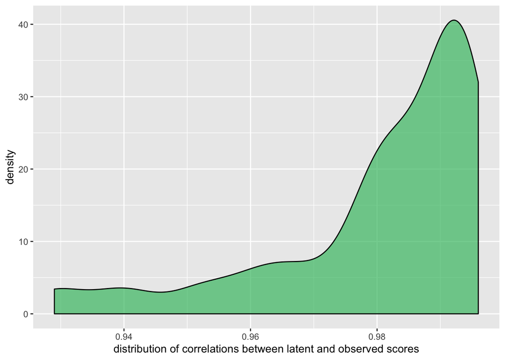

```r
# plots
## all
ggplot(latent_observed_correlation_results, aes(r, fill = "dummy")) +
  geom_density(alpha = 0.7) +
  scale_fill_viridis_d(begin = 0.7, end = 0.7) +
  theme(legend.position = "none") +
  xlab("distribution of correlations between latent and observed scores")
```

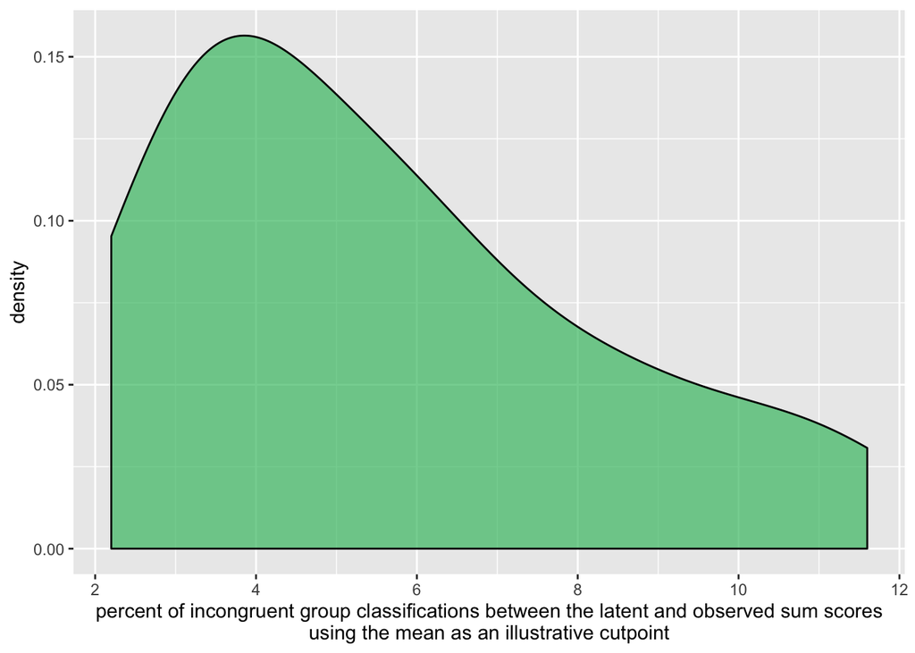

```r
# ## by categorical decision
# ggplot(latent_observed_correlation_results, aes(r, fill = `Confirmatory factor structure`)) +
#   geom_density(alpha = 0.7, adjust = 1.5) +
#   scale_fill_viridis_d(begin = 0.2, end = 0.8) +
#   #theme(legend.position = "none") +
#   xlab("distribution of correlations between latent and observed scores")


## all
ggplot(latent_observed_correlation_results, aes(percent_misclassification, fill = "dummy")) +
  geom_density(alpha = 0.7) +
  scale_fill_viridis_d(begin = 0.7, end = 0.7) +
  theme(legend.position = "none") +
  xlab("percent of incongruent group classifications between the latent and observed sum scores\nusing the mean as an illustrative cutpoint")
```

```r
# ## by categorical decision
# ggplot(latent_observed_correlation_results, aes(percent_misclassification, fill = `Confirmatory factor structure`)) +
#   geom_density(alpha = 0.7) +
#   scale_fill_viridis_d(begin = 0.2, end = 0.8) +
#   theme(legend.position = "none") +
#   xlab("percent of incongruent group classifications between the latent and observed sum scores\nusing the mean as an illustrative cutpoint")
```

## Between-group differences on the latent vs. the observed scales

i.e., an effect size for measurement invariance.

```r
## fit a CFA and return its model fit statistics
fit_constrained_cfa <- function(data, model) {
  require(lavaan)
  require(tidyverse)

  # fit cfa
  cfa_data <- data %>%
    dplyr::select(-sex, -age)

  # sem model
  fit <- cfa(model,
             data = cfa_data,
             order = c("1", "2", "3", "4", "5", "6"),
             estimator = "WLSMV",
             group.equal = c("loadings", "intercepts"))

  return(fit)
}

# fit models
bfi_e_fit_constrained    <- fit_constrained_cfa(data = bfi_e_data,    model = bfi_e_model)
bfi_c_fit_constrained    <- fit_constrained_cfa(data = bfi_c_data,    model = bfi_c_model)
bfi_n_fit_constrained    <- fit_constrained_cfa(data = bfi_n_data,    model = bfi_n_model)
bfi_a_fit_constrained    <- fit_constrained_cfa(data = bfi_a_data,    model = bfi_a_model)
bfi_o_fit_constrained    <- fit_constrained_cfa(data = bfi_o_data,    model = bfi_o_model)
bidr_im_fit_constrained  <- fit_constrained_cfa(data = bidr_im_data,  model = bidr_im_model)
bidr_sde_fit_constrained <- fit_constrained_cfa(data = bidr_sde_data, model = bidr_sde_model)
bjw_fit_constrained      <- fit_constrained_cfa(data = bjw_data,      model = bjw_model)
brs_fit_constrained      <- fit_constrained_cfa(data = brs_data,      model = brs_model)
he_fit_constrained       <- fit_constrained_cfa(data = he_data,       model = he_model)
icat_o_fit_constrained   <- fit_constrained_cfa(data = icat_o_data,   model = icat_o_model)
icat_s_fit_constrained   <- fit_constrained_cfa(data = icat_s_data,   model = icat_s_model)
nfc_fit_constrained      <- fit_constrained_cfa(data = nfc_data,      model = nfc_model)
nfcc_p_fit_constrained   <- fit_constrained_cfa(data = nfcc_p_data,   model = nfcc_p_model)
nfcc_d_fit_constrained   <- fit_constrained_cfa(data = nfcc_d_data,   model = nfcc_d_model)
nfcc_c_fit_constrained   <- fit_constrained_cfa(data = nfcc_c_data,   model = nfcc_c_model)
nfcc_a_fit_constrained   <- fit_constrained_cfa(data = nfcc_a_data,   model = nfcc_a_model)
nfcc_o_fit_constrained   <- fit_constrained_cfa(data = nfcc_o_data,   model = nfcc_o_model)
pe_fit_constrained       <- fit_constrained_cfa(data = pe_data,       model = pe_model)
pns_fit_constrained      <- fit_constrained_cfa(data = pns_data,      model = pns_model)
rse_fit_constrained      <- fit_constrained_cfa(data = rse_data,      model = rse_model)
rwa_fit_constrained      <- fit_constrained_cfa(data = rwa_data,      model = rwa_model)
sdo_fit_constrained      <- fit_constrained_cfa(data = sdo_data,      model = sdo_model)
sm_fit_constrained       <- fit_constrained_cfa(data = sm_data,       model = sm_model)
soc_ic_fit_constrained   <- fit_constrained_cfa(data = soc_ic_data,   model = soc_ic_model)
soc_pe_fit_constrained   <- fit_constrained_cfa(data = soc_pe_data,   model = soc_pe_model)


# calculate latent and observed sum scores
constrained_latent_observed_bfi_e <- bfi_e_data %>%
  mutate(latent = as.data.frame(lavPredict(bfi_e_fit_constrained))$E) %>%
  rowwise() %>%
  mutate(observed = mean(c(bfi_e1, bfi_e2, bfi_e3, bfi_e4, bfi_e5, bfi_e6, bfi_e7, bfi_e8))) %>%
  ungroup() %>%
  select(age, sex,
         latent, observed)

constrained_latent_observed_bfi_c <- bfi_c_data %>%
  mutate(latent = as.data.frame(lavPredict(bfi_c_fit_constrained))$C) %>%
  rowwise() %>%
  mutate(observed = mean(c(bfi_c1, bfi_c2, bfi_c3, bfi_c4, bfi_c5, bfi_c6, bfi_c7, bfi_c8, bfi_c9))) %>%
  ungroup() %>%
  select(age, sex,
         latent, observed)

constrained_latent_observed_bfi_n <- bfi_n_data %>%
  mutate(latent = as.data.frame(lavPredict(bfi_n_fit_constrained))$N) %>%
  rowwise() %>%
  mutate(observed = mean(c(bfi_n1, bfi_n2, bfi_n3, bfi_n4, bfi_n5, bfi_n6, bfi_n7, bfi_n8))) %>%
  ungroup() %>%
  select(age, sex,
         latent, observed)

constrained_latent_observed_bfi_a <- bfi_a_data %>%
  mutate(latent = as.data.frame(lavPredict(bfi_a_fit_constrained))$A) %>%
  rowwise() %>%
  mutate(observed = mean(c(bfi_a1, bfi_a2, bfi_a3, bfi_a4, bfi_a5, bfi_a6, bfi_a7, bfi_a8, bfi_a9))) %>%
  ungroup() %>%
  select(age, sex,
         latent, observed)

constrained_latent_observed_bfi_o <- bfi_o_data %>%
  mutate(latent = as.data.frame(lavPredict(bfi_o_fit_constrained))$O) %>%
  rowwise() %>%
  mutate(observed = mean(c(bfi_o1, bfi_o2, bfi_o3, bfi_o4, bfi_o5, bfi_o6, bfi_o7, bfi_o8, bfi_o9, bfi_o10))) %>%
  ungroup() %>%
  select(age, sex,
         latent, observed)

constrained_latent_observed_bidr_im <- bidr_im_data %>%
  mutate(latent = as.data.frame(lavPredict(bidr_im_fit_constrained))$IM) %>%
  rowwise() %>%
  mutate(observed = mean(c(bidr_im1, bidr_im2, bidr_im3, bidr_im4, bidr_im5, bidr_im6, bidr_im7, bidr_im8, bidr_im9, bidr_im10, bidr_im11, bidr_im12, bidr_im13, bidr_im14, bidr_im15, bidr_im16, bidr_im17, bidr_im18))) %>%
  ungroup() %>%
  select(age, sex,
         latent, observed)

constrained_latent_observed_bidr_sde <- bidr_sde_data %>%
  mutate(latent = as.data.frame(lavPredict(bidr_sde_fit_constrained))$SDE) %>%
  rowwise() %>%
  mutate(observed = mean(c(bidr_sde1, bidr_sde2, bidr_sde3, bidr_sde4, bidr_sde5, bidr_sde6, bidr_sde7, bidr_sde8, bidr_sde9, bidr_sde10, bidr_sde11, bidr_sde12, bidr_sde13, bidr_sde14, bidr_sde15, bidr_sde16, bidr_sde17, bidr_sde18))) %>%
  ungroup() %>%
  select(age, sex,
         latent, observed)

constrained_latent_observed_bjw <- bjw_data %>%
  mutate(latent = as.data.frame(lavPredict(bjw_fit_constrained))$BJW) %>%
  rowwise() %>%
  mutate(observed = mean(c(bjw1, bjw2, bjw3, bjw4, bjw5, bjw6))) %>%
  ungroup() %>%
  select(age, sex,
         latent, observed)

constrained_latent_observed_brs <- brs_data %>%
  mutate(latent = as.data.frame(lavPredict(brs_fit_constrained))$BRS) %>%
  rowwise() %>%
  mutate(observed = mean(c(brs1, brs2, brs3, brs4, brs5, brs6, brs7, brs8, brs9, brs10, brs11, brs12, brs13, brs14, brs15, brs16))) %>%
  ungroup() %>%
  select(age, sex,
         latent, observed)

constrained_latent_observed_he <- he_data %>%
  mutate(latent = as.data.frame(lavPredict(he_fit_constrained))$HE) %>%
  rowwise() %>%
  mutate(observed = mean(c(he1, he2, he3, he4, he5, he6, he7, he8, he9, he10))) %>%
  ungroup() %>%
  select(age, sex,
         latent, observed)
```

```r
constrained_latent_observed_icat_o <- icat_o_data %>%
  mutate(latent = as.data.frame(lavPredict(icat_o_fit_constrained))$ICAT_O) %>%
  rowwise() %>%
  mutate(observed = mean(c(icat_o1, icat_o2, icat_o3, icat_o4, icat_o5, icat_o6, icat_o7, icat_o8, icat_o9))) %>%
  ungroup() %>%
  select(age, sex,
         latent, observed)

constrained_latent_observed_icat_s <- icat_s_data %>%
  mutate(latent = as.data.frame(lavPredict(icat_s_fit_constrained))$ICAT_S) %>%
  rowwise() %>%
  mutate(observed = mean(c(icat_s1, icat_s2, icat_s3, icat_s4, icat_s5, icat_s6, icat_s7, icat_s8, icat_s9))) %>%
  ungroup() %>%
  select(age, sex,
         latent, observed)

constrained_latent_observed_nfc <- nfc_data %>%
  mutate(latent = as.data.frame(lavPredict(nfc_fit_constrained))$NFC) %>%
  rowwise() %>%
  mutate(observed = mean(c(nfc1, nfc2, nfc3, nfc4, nfc5, nfc6, nfc7, nfc8, nfc9, nfc10, nfc11, nfc12, nfc13, nfc14, nfc15, nfc16, nfc17, nfc18))) %>%
  ungroup() %>%
  select(age, sex,
         latent, observed)

constrained_latent_observed_nfcc_p <- nfcc_p_data %>%
  mutate(latent = as.data.frame(lavPredict(nfcc_p_fit_constrained))$P) %>%
  rowwise() %>%
  mutate(observed = mean(c(nfcc_p1, nfcc_p2, nfcc_p3, nfcc_p4, nfcc_p5, nfcc_p6, nfcc_p7, nfcc_p8))) %>%
  ungroup() %>%
  select(age, sex,
         latent, observed)

constrained_latent_observed_nfcc_d <- nfcc_d_data %>%
  mutate(latent = as.data.frame(lavPredict(nfcc_d_fit_constrained))$D) %>%
  rowwise() %>%
  mutate(observed = mean(c(nfcc_d1, nfcc_d2, nfcc_d3, nfcc_d4, nfcc_d5, nfcc_d6, nfcc_d7))) %>%
  ungroup() %>%
  select(age, sex,
         latent, observed)

constrained_latent_observed_nfcc_c <- nfcc_c_data %>%
  mutate(latent = as.data.frame(lavPredict(nfcc_c_fit_constrained))$C) %>%
  rowwise() %>%
  mutate(observed = mean(c(nfcc_c1, nfcc_c2, nfcc_c3, nfcc_c4, nfcc_c5, nfcc_c6, nfcc_c7, nfcc_c8))) %>%
  ungroup() %>%
  select(age, sex,
         latent, observed)

constrained_latent_observed_nfcc_a <- nfcc_a_data %>%
  mutate(latent = as.data.frame(lavPredict(nfcc_a_fit_constrained))$A) %>%
  rowwise() %>%
  mutate(observed = mean(c(nfcc_a1, nfcc_a2, nfcc_a3, nfcc_a4, nfcc_a5, nfcc_a6, nfcc_a7, nfcc_a8))) %>%
  ungroup() %>%
  select(age, sex,
         latent, observed)

constrained_latent_observed_nfcc_o <- nfcc_o_data %>%
  mutate(latent = as.data.frame(lavPredict(nfcc_o_fit_constrained))$O) %>%
  rowwise() %>%
  mutate(observed = mean(c(nfcc_o1, nfcc_o2, nfcc_o3, nfcc_o4, nfcc_o5, nfcc_o6, nfcc_o7))) %>%
  ungroup() %>%
  select(age, sex,
         latent, observed)

constrained_latent_observed_pe <- pe_data %>%
  mutate(latent = as.data.frame(lavPredict(pe_fit_constrained))$PE) %>%
  rowwise() %>%
  mutate(observed = mean(c(pe1, pe2, pe3, pe4, pe5, pe6, pe7, pe8, pe9, pe10, pe11))) %>%
  ungroup() %>%
  select(age, sex,
         latent, observed)

constrained_latent_observed_pns <- pns_data %>%
  mutate(latent = as.data.frame(lavPredict(pns_fit_constrained))$PNS) %>%
  rowwise() %>%
  mutate(observed = mean(c(pns1, pns2, pns3, pns4, pns5, pns6, pns7, pns8, pns9, pns10, pns11, pns12))) %>%
  ungroup() %>%
  select(age, sex,
         latent, observed)

constrained_latent_observed_rse <- rse_data %>%
  mutate(latent = as.data.frame(lavPredict(rse_fit_constrained))$RSE) %>%
  rowwise() %>%
  mutate(observed = mean(c(rse1, rse2, rse3, rse4, rse5, rse6, rse7, rse8, rse9, rse10))) %>%
  ungroup() %>%
  select(age, sex,
         latent, observed)

constrained_latent_observed_rwa <- rwa_data %>%
  mutate(latent = as.data.frame(lavPredict(rwa_fit_constrained))$RWA) %>%
  rowwise() %>%
  mutate(observed = mean(c(rwa1, rwa2, rwa3, rwa4, rwa5, rwa6, rwa7, rwa8, rwa9, rwa10, rwa11, rwa12, rwa13, rwa14, rwa15, rwa16, rwa17, rwa18, rwa19, rwa20))) %>%
  ungroup() %>%
  select(age, sex,
         latent, observed)

constrained_latent_observed_sdo <- sdo_data %>%
  mutate(latent = as.data.frame(lavPredict(sdo_fit_constrained))$SDO) %>%
  rowwise() %>%
  mutate(observed = mean(c(sdo1, sdo2, sdo3, sdo4, sdo5, sdo6, sdo7, sdo8, sdo9, sdo10, sdo11, sdo12))) %>%
  ungroup() %>%
  select(age, sex,
         latent, observed)

constrained_latent_observed_sm <- sm_data %>%
  mutate(latent = as.data.frame(lavPredict(sm_fit_constrained))$SM) %>%
  rowwise() %>%
  mutate(observed = mean(c(sm1, sm2, sm3, sm4, sm5, sm6, sm7, sm8, sm9, sm10, sm11, sm12, sm13, sm14, sm15, sm16, sm17, sm18))) %>%
  ungroup() %>%
  select(age, sex,
         latent, observed)

constrained_latent_observed_soc_ic <- soc_ic_data %>%
  mutate(latent = as.data.frame(lavPredict(soc_ic_fit_constrained))$IC) %>%
  rowwise() %>%
  mutate(observed = mean(c(soc_ic1, soc_ic2, soc_ic3, soc_ic4, soc_ic5, soc_ic6, soc_ic7, soc_ic8, soc_ic9))) %>%
  ungroup() %>%
  select(age, sex,
         latent, observed)

constrained_latent_observed_soc_pe <- soc_pe_data %>%
  mutate(latent = as.data.frame(lavPredict(soc_pe_fit_constrained))$PE) %>%
  rowwise() %>%
  mutate(observed = mean(c(soc_pe1, soc_pe2, soc_pe3, soc_pe4, soc_pe5, soc_pe6, soc_pe7, soc_pe8, soc_pe9, soc_pe10))) %>%
  ungroup() %>%
  select(age, sex,
         latent, observed)


es_constrained_latent_sex_bfi_e      <- effsize::cohen.d(latent ~ sex,     data = constrained_latent_observed_bfi_e)
es_constrained_latent_sex_bfi_c      <- effsize::cohen.d(latent ~ sex,     data = constrained_latent_observed_bfi_c)
es_constrained_latent_sex_bfi_n      <- effsize::cohen.d(latent ~ sex,     data = constrained_latent_observed_bfi_n)
es_constrained_latent_sex_bfi_a      <- effsize::cohen.d(latent ~ sex,     data = constrained_latent_observed_bfi_a)
es_constrained_latent_sex_bfi_o      <- effsize::cohen.d(latent ~ sex,     data = constrained_latent_observed_bfi_o)
es_constrained_latent_sex_bidr_im    <- effsize::cohen.d(latent ~ sex,     data = constrained_latent_observed_bidr_im)
es_constrained_latent_sex_bidr_sde   <- effsize::cohen.d(latent ~ sex,     data = constrained_latent_observed_bidr_sde)
es_constrained_latent_sex_bjw        <- effsize::cohen.d(latent ~ sex,     data = constrained_latent_observed_bjw)
es_constrained_latent_sex_brs        <- effsize::cohen.d(latent ~ sex,     data = constrained_latent_observed_brs)
es_constrained_latent_sex_he         <- effsize::cohen.d(latent ~ sex,     data = constrained_latent_observed_he)
es_constrained_latent_sex_icat_o     <- effsize::cohen.d(latent ~ sex,     data = constrained_latent_observed_icat_o)
es_constrained_latent_sex_icat_s     <- effsize::cohen.d(latent ~ sex,     data = constrained_latent_observed_icat_s)
es_constrained_latent_sex_nfc        <- effsize::cohen.d(latent ~ sex,     data = constrained_latent_observed_nfc)
es_constrained_latent_sex_nfcc_p     <- effsize::cohen.d(latent ~ sex,     data = constrained_latent_observed_nfcc_p)
es_constrained_latent_sex_nfcc_d     <- effsize::cohen.d(latent ~ sex,     data = constrained_latent_observed_nfcc_d)
es_constrained_latent_sex_nfcc_c     <- effsize::cohen.d(latent ~ sex,     data = constrained_latent_observed_nfcc_c)
es_constrained_latent_sex_nfcc_a     <- effsize::cohen.d(latent ~ sex,     data = constrained_latent_observed_nfcc_a)
es_constrained_latent_sex_nfcc_o     <- effsize::cohen.d(latent ~ sex,     data = constrained_latent_observed_nfcc_o)
es_constrained_latent_sex_pe         <- effsize::cohen.d(latent ~ sex,     data = constrained_latent_observed_pe)
es_constrained_latent_sex_pns        <- effsize::cohen.d(latent ~ sex,     data = constrained_latent_observed_pns)
es_constrained_latent_sex_rse        <- effsize::cohen.d(latent ~ sex,     data = constrained_latent_observed_rse)
es_constrained_latent_sex_rwa        <- effsize::cohen.d(latent ~ sex,     data = constrained_latent_observed_rwa)
es_constrained_latent_sex_sdo        <- effsize::cohen.d(latent ~ sex,     data = constrained_latent_observed_sdo)
es_constrained_latent_sex_sm         <- effsize::cohen.d(latent ~ sex,     data = constrained_latent_observed_sm)
es_constrained_latent_sex_soc_ic     <- effsize::cohen.d(latent ~ sex,     data = constrained_latent_observed_soc_ic)
es_constrained_latent_sex_soc_pe     <- effsize::cohen.d(latent ~ sex,     data = constrained_latent_observed_soc_pe)
```

```r
es_constrained_latent_age_bfi_e      <- effsize::cohen.d(latent ~ age,     data = constrained_latent_observed_bfi_e)
es_constrained_latent_age_bfi_c      <- effsize::cohen.d(latent ~ age,     data = constrained_latent_observed_bfi_c)
es_constrained_latent_age_bfi_n      <- effsize::cohen.d(latent ~ age,     data = constrained_latent_observed_bfi_n)
es_constrained_latent_age_bfi_a      <- effsize::cohen.d(latent ~ age,     data = constrained_latent_observed_bfi_a)
es_constrained_latent_age_bfi_o      <- effsize::cohen.d(latent ~ age,     data = constrained_latent_observed_bfi_o)
es_constrained_latent_age_bidr_im    <- effsize::cohen.d(latent ~ age,     data = constrained_latent_observed_bidr_im)
es_constrained_latent_age_bidr_sde   <- effsize::cohen.d(latent ~ age,     data = constrained_latent_observed_bidr_sde)
es_constrained_latent_age_bjw        <- effsize::cohen.d(latent ~ age,     data = constrained_latent_observed_bjw)
es_constrained_latent_age_brs        <- effsize::cohen.d(latent ~ age,     data = constrained_latent_observed_brs)
es_constrained_latent_age_he         <- effsize::cohen.d(latent ~ age,     data = constrained_latent_observed_he)
es_constrained_latent_age_icat_o     <- effsize::cohen.d(latent ~ age,     data = constrained_latent_observed_icat_o)
es_constrained_latent_age_icat_s     <- effsize::cohen.d(latent ~ age,     data = constrained_latent_observed_icat_s)
es_constrained_latent_age_nfc        <- effsize::cohen.d(latent ~ age,     data = constrained_latent_observed_nfc)
es_constrained_latent_age_nfcc_p     <- effsize::cohen.d(latent ~ age,     data = constrained_latent_observed_nfcc_p)
es_constrained_latent_age_nfcc_d     <- effsize::cohen.d(latent ~ age,     data = constrained_latent_observed_nfcc_d)
es_constrained_latent_age_nfcc_c     <- effsize::cohen.d(latent ~ age,     data = constrained_latent_observed_nfcc_c)
es_constrained_latent_age_nfcc_a     <- effsize::cohen.d(latent ~ age,     data = constrained_latent_observed_nfcc_a)
es_constrained_latent_age_nfcc_o     <- effsize::cohen.d(latent ~ age,     data = constrained_latent_observed_nfcc_o)
es_constrained_latent_age_pe         <- effsize::cohen.d(latent ~ age,     data = constrained_latent_observed_pe)
es_constrained_latent_age_pns        <- effsize::cohen.d(latent ~ age,     data = constrained_latent_observed_pns)
es_constrained_latent_age_rse        <- effsize::cohen.d(latent ~ age,     data = constrained_latent_observed_rse)
es_constrained_latent_age_rwa        <- effsize::cohen.d(latent ~ age,     data = constrained_latent_observed_rwa)
es_constrained_latent_age_sdo        <- effsize::cohen.d(latent ~ age,     data = constrained_latent_observed_sdo)
es_constrained_latent_age_sm         <- effsize::cohen.d(latent ~ age,     data = constrained_latent_observed_sm)
es_constrained_latent_age_soc_ic     <- effsize::cohen.d(latent ~ age,     data = constrained_latent_observed_soc_ic)
es_constrained_latent_age_soc_pe     <- effsize::cohen.d(latent ~ age,     data = constrained_latent_observed_soc_pe)

es_constrained_observed_sex_bfi_e    <- effsize::cohen.d(observed ~ sex,   data = constrained_latent_observed_bfi_e)
es_constrained_observed_sex_bfi_c    <- effsize::cohen.d(observed ~ sex,   data = constrained_latent_observed_bfi_c)
es_constrained_observed_sex_bfi_n    <- effsize::cohen.d(observed ~ sex,   data = constrained_latent_observed_bfi_n)
es_constrained_observed_sex_bfi_a    <- effsize::cohen.d(observed ~ sex,   data = constrained_latent_observed_bfi_a)
es_constrained_observed_sex_bfi_o    <- effsize::cohen.d(observed ~ sex,   data = constrained_latent_observed_bfi_o)
es_constrained_observed_sex_bidr_im  <- effsize::cohen.d(observed ~ sex,   data = constrained_latent_observed_bidr_im)
es_constrained_observed_sex_bidr_sde <- effsize::cohen.d(observed ~ sex,   data = constrained_latent_observed_bidr_sde)
es_constrained_observed_sex_bjw      <- effsize::cohen.d(observed ~ sex,   data = constrained_latent_observed_bjw)
es_constrained_observed_sex_brs      <- effsize::cohen.d(observed ~ sex,   data = constrained_latent_observed_brs)
es_constrained_observed_sex_he       <- effsize::cohen.d(observed ~ sex,   data = constrained_latent_observed_he)
es_constrained_observed_sex_icat_o   <- effsize::cohen.d(observed ~ sex,   data = constrained_latent_observed_icat_o)
es_constrained_observed_sex_icat_s   <- effsize::cohen.d(observed ~ sex,   data = constrained_latent_observed_icat_s)
es_constrained_observed_sex_nfc      <- effsize::cohen.d(observed ~ sex,   data = constrained_latent_observed_nfc)
es_constrained_observed_sex_nfcc_p   <- effsize::cohen.d(observed ~ sex,   data = constrained_latent_observed_nfcc_p)
es_constrained_observed_sex_nfcc_d   <- effsize::cohen.d(observed ~ sex,   data = constrained_latent_observed_nfcc_d)
es_constrained_observed_sex_nfcc_c   <- effsize::cohen.d(observed ~ sex,   data = constrained_latent_observed_nfcc_c)
es_constrained_observed_sex_nfcc_a   <- effsize::cohen.d(observed ~ sex,   data = constrained_latent_observed_nfcc_a)
es_constrained_observed_sex_nfcc_o   <- effsize::cohen.d(observed ~ sex,   data = constrained_latent_observed_nfcc_o)
es_constrained_observed_sex_pe       <- effsize::cohen.d(observed ~ sex,   data = constrained_latent_observed_pe)
es_constrained_observed_sex_pns      <- effsize::cohen.d(observed ~ sex,   data = constrained_latent_observed_pns)
es_constrained_observed_sex_rse      <- effsize::cohen.d(observed ~ sex,   data = constrained_latent_observed_rse)
es_constrained_observed_sex_rwa      <- effsize::cohen.d(observed ~ sex,   data = constrained_latent_observed_rwa)
es_constrained_observed_sex_sdo      <- effsize::cohen.d(observed ~ sex,   data = constrained_latent_observed_sdo)
es_constrained_observed_sex_sm       <- effsize::cohen.d(observed ~ sex,   data = constrained_latent_observed_sm)
es_constrained_observed_sex_soc_ic   <- effsize::cohen.d(observed ~ sex,   data = constrained_latent_observed_soc_ic)
es_constrained_observed_sex_soc_pe   <- effsize::cohen.d(observed ~ sex,   data = constrained_latent_observed_soc_pe)
```

```r
es_constrained_observed_age_bfi_e    <- effsize::cohen.d(observed ~ age,   data = constrained_latent_observed_bfi_e)
es_constrained_observed_age_bfi_c    <- effsize::cohen.d(observed ~ age,   data = constrained_latent_observed_bfi_c)
es_constrained_observed_age_bfi_n    <- effsize::cohen.d(observed ~ age,   data = constrained_latent_observed_bfi_n)
es_constrained_observed_age_bfi_a    <- effsize::cohen.d(observed ~ age,   data = constrained_latent_observed_bfi_a)
es_constrained_observed_age_bfi_o    <- effsize::cohen.d(observed ~ age,   data = constrained_latent_observed_bfi_o)
es_constrained_observed_age_bidr_im  <- effsize::cohen.d(observed ~ age,   data = constrained_latent_observed_bidr_im)
es_constrained_observed_age_bidr_sde <- effsize::cohen.d(observed ~ age,   data = constrained_latent_observed_bidr_sde)
es_constrained_observed_age_bjw      <- effsize::cohen.d(observed ~ age,   data = constrained_latent_observed_bjw)
es_constrained_observed_age_brs      <- effsize::cohen.d(observed ~ age,   data = constrained_latent_observed_brs)
es_constrained_observed_age_he       <- effsize::cohen.d(observed ~ age,   data = constrained_latent_observed_he)
es_constrained_observed_age_icat_o   <- effsize::cohen.d(observed ~ age,   data = constrained_latent_observed_icat_o)
es_constrained_observed_age_icat_s   <- effsize::cohen.d(observed ~ age,   data = constrained_latent_observed_icat_s)
es_constrained_observed_age_nfc      <- effsize::cohen.d(observed ~ age,   data = constrained_latent_observed_nfc)
es_constrained_observed_age_nfcc_p   <- effsize::cohen.d(observed ~ age,   data = constrained_latent_observed_nfcc_p)
es_constrained_observed_age_nfcc_d   <- effsize::cohen.d(observed ~ age,   data = constrained_latent_observed_nfcc_d)
es_constrained_observed_age_nfcc_c   <- effsize::cohen.d(observed ~ age,   data = constrained_latent_observed_nfcc_c)
es_constrained_observed_age_nfcc_a   <- effsize::cohen.d(observed ~ age,   data = constrained_latent_observed_nfcc_a)
es_constrained_observed_age_nfcc_o   <- effsize::cohen.d(observed ~ age,   data = constrained_latent_observed_nfcc_o)
es_constrained_observed_age_pe       <- effsize::cohen.d(observed ~ age,   data = constrained_latent_observed_pe)
es_constrained_observed_age_pns      <- effsize::cohen.d(observed ~ age,   data = constrained_latent_observed_pns)
es_constrained_observed_age_rse      <- effsize::cohen.d(observed ~ age,   data = constrained_latent_observed_rse)
es_constrained_observed_age_rwa      <- effsize::cohen.d(observed ~ age,   data = constrained_latent_observed_rwa)
es_constrained_observed_age_sdo      <- effsize::cohen.d(observed ~ age,   data = constrained_latent_observed_sdo)
es_constrained_observed_age_sm       <- effsize::cohen.d(observed ~ age,   data = constrained_latent_observed_sm)
es_constrained_observed_age_soc_ic   <- effsize::cohen.d(observed ~ age,   data = constrained_latent_observed_soc_ic)
es_constrained_observed_age_soc_pe   <- effsize::cohen.d(observed ~ age,   data = constrained_latent_observed_soc_pe)


group_differences_results <-
  data.frame(scale_name = c("bfi_a", "bfi_c", "bfi_e", "bfi_n", "bfi_o", "bidr_im", "bidr_sde", "bjw", "brs", "he", "icat_o", "icat_s", "nfc", "nfcc_p", "nfcc_d", "nfcc_c", "nfcc_a", "nfcc_o", "pe", "pns", "rse", "rwa", "sdo", "sm", "soc_ic", "soc_pe"),
             group_comparison = c("age", "age", "age", "age", "age", "age", "age", "age", "age", "age", "age", "age", "age", "age", "age", "age", "age", "age", "age", "age", "age", "age", "age", "age", "age", "age", "sex", "sex", "sex", "sex", "sex", "sex", "sex", "sex", "sex", "sex", "sex", "sex", "sex", "sex", "sex", "sex", "sex", "sex", "sex", "sex", "sex", "sex", "sex", "sex", "sex", "sex"),
             latent_cohens_d = c(es_constrained_latent_age_bfi_a$estimate,
                                 es_constrained_latent_age_bfi_c$estimate,
                                 es_constrained_latent_age_bfi_e$estimate,
                                 es_constrained_latent_age_bfi_n$estimate,
                                 es_constrained_latent_age_bfi_o$estimate,
                                 es_constrained_latent_age_bidr_im$estimate,
                                 es_constrained_latent_age_bidr_sde$estimate,
                                 es_constrained_latent_age_bjw$estimate,
                                 es_constrained_latent_age_brs$estimate,
                                 es_constrained_latent_age_he$estimate,
                                 es_constrained_latent_age_icat_o$estimate,
                                 es_constrained_latent_age_icat_s$estimate,
                                 es_constrained_latent_age_nfc$estimate,
                                 es_constrained_latent_age_nfcc_p$estimate,
                                 es_constrained_latent_age_nfcc_d$estimate,
                                 es_constrained_latent_age_nfcc_c$estimate,
                                 es_constrained_latent_age_nfcc_a$estimate,
                                 es_constrained_latent_age_nfcc_o$estimate,
                                 es_constrained_latent_age_pe$estimate,
                                 es_constrained_latent_age_pns$estimate,
                                 es_constrained_latent_age_rse$estimate,
                                 es_constrained_latent_age_rwa$estimate,
                                 es_constrained_latent_age_sdo$estimate,
                                 es_constrained_latent_age_sm$estimate,
                                 es_constrained_latent_age_soc_ic$estimate,
                                 es_constrained_latent_age_soc_pe$estimate,
                                 es_constrained_latent_sex_bfi_a$estimate,
                                 es_constrained_latent_sex_bfi_c$estimate,
                                 es_constrained_latent_sex_bfi_e$estimate,
                                 es_constrained_latent_sex_bfi_n$estimate,
                                 es_constrained_latent_sex_bfi_o$estimate,
                                 es_constrained_latent_sex_bidr_im$estimate,
                                 es_constrained_latent_sex_bidr_sde$estimate,
                                 es_constrained_latent_sex_bjw$estimate,
                                 es_constrained_latent_sex_brs$estimate,
                                 es_constrained_latent_sex_he$estimate,
                                 es_constrained_latent_sex_icat_o$estimate,
                                 es_constrained_latent_sex_icat_s$estimate,
                                 es_constrained_latent_sex_nfc$estimate,
                                 es_constrained_latent_sex_nfcc_p$estimate,
                                 es_constrained_latent_sex_nfcc_d$estimate,
                                 es_constrained_latent_sex_nfcc_c$estimate,
                                 es_constrained_latent_sex_nfcc_a$estimate,
                                 es_constrained_latent_sex_nfcc_o$estimate,
                                 es_constrained_latent_sex_pe$estimate,
                                 es_constrained_latent_sex_pns$estimate,
                                 es_constrained_latent_sex_rse$estimate,
                                 es_constrained_latent_sex_rwa$estimate,
                                 es_constrained_latent_sex_sdo$estimate,
                                 es_constrained_latent_sex_sm$estimate,
                                 es_constrained_latent_sex_soc_ic$estimate,
                                 es_constrained_latent_sex_soc_pe$estimate),
             latent_cohens_d_ci_lwr = c(es_constrained_latent_age_bfi_a$conf.int[1],
                                        es_constrained_latent_age_bfi_c$conf.int[1],
                                        es_constrained_latent_age_bfi_e$conf.int[1],
                                        es_constrained_latent_age_bfi_n$conf.int[1],
                                        es_constrained_latent_age_bfi_o$conf.int[1],
                                        es_constrained_latent_age_bidr_im$conf.int[1],
                                        es_constrained_latent_age_bidr_sde$conf.int[1],
                                        es_constrained_latent_age_bjw$conf.int[1],
                                        es_constrained_latent_age_brs$conf.int[1],
                                        es_constrained_latent_age_he$conf.int[1],
                                        es_constrained_latent_age_icat_o$conf.int[1],
                                        es_constrained_latent_age_icat_s$conf.int[1],
                                        es_constrained_latent_age_nfc$conf.int[1],
                                        es_constrained_latent_age_nfcc_p$conf.int[1],
                                        es_constrained_latent_age_nfcc_d$conf.int[1],
                                        es_constrained_latent_age_nfcc_c$conf.int[1],
                                        es_constrained_latent_age_nfcc_a$conf.int[1],
                                        es_constrained_latent_age_nfcc_o$conf.int[1],
                                        es_constrained_latent_age_pe$conf.int[1],
                                        es_constrained_latent_age_pns$conf.int[1],
                                        es_constrained_latent_age_rse$conf.int[1],
                                        es_constrained_latent_age_rwa$conf.int[1],
                                        es_constrained_latent_age_sdo$conf.int[1],
                                        es_constrained_latent_age_sm$conf.int[1],
                                        es_constrained_latent_age_soc_ic$conf.int[1],
                                        es_constrained_latent_age_soc_pe$conf.int[1],
                                        es_constrained_latent_sex_bfi_a$conf.int[1],
                                        es_constrained_latent_sex_bfi_c$conf.int[1],
                                        es_constrained_latent_sex_bfi_e$conf.int[1],
                                        es_constrained_latent_sex_bfi_n$conf.int[1],
                                        es_constrained_latent_sex_bfi_o$conf.int[1],
                                        es_constrained_latent_sex_bidr_im$conf.int[1],
                                        es_constrained_latent_sex_bidr_sde$conf.int[1],
                                        es_constrained_latent_sex_bjw$conf.int[1],
                                        es_constrained_latent_sex_brs$conf.int[1],
                                        es_constrained_latent_sex_he$conf.int[1],
                                        es_constrained_latent_sex_icat_o$conf.int[1],
                                        es_constrained_latent_sex_icat_s$conf.int[1],
                                        es_constrained_latent_sex_nfc$conf.int[1],
                                        es_constrained_latent_sex_nfcc_p$conf.int[1],
                                        es_constrained_latent_sex_nfcc_d$conf.int[1],
                                        es_constrained_latent_sex_nfcc_c$conf.int[1],
                                        es_constrained_latent_sex_nfcc_a$conf.int[1],
                                        es_constrained_latent_sex_nfcc_o$conf.int[1],
                                        es_constrained_latent_sex_pe$conf.int[1],
                                        es_constrained_latent_sex_pns$conf.int[1],
                                        es_constrained_latent_sex_rse$conf.int[1],
                                        es_constrained_latent_sex_rwa$conf.int[1],
                                        es_constrained_latent_sex_sdo$conf.int[1],
                                        es_constrained_latent_sex_sm$conf.int[1],
                                        es_constrained_latent_sex_soc_ic$conf.int[1],
                                        es_constrained_latent_sex_soc_pe$conf.int[1]),
```

```r
             latent_cohens_d_ci_upr = c(es_constrained_latent_age_bfi_a$conf.int[2],
                                        es_constrained_latent_age_bfi_c$conf.int[2],
                                        es_constrained_latent_age_bfi_e$conf.int[2],
                                        es_constrained_latent_age_bfi_n$conf.int[2],
                                        es_constrained_latent_age_bfi_o$conf.int[2],
                                        es_constrained_latent_age_bidr_im$conf.int[2],
                                        es_constrained_latent_age_bidr_sde$conf.int[2],
                                        es_constrained_latent_age_bjw$conf.int[2],
                                        es_constrained_latent_age_brs$conf.int[2],
                                        es_constrained_latent_age_he$conf.int[2],
                                        es_constrained_latent_age_icat_o$conf.int[2],
                                        es_constrained_latent_age_icat_s$conf.int[2],
                                        es_constrained_latent_age_nfc$conf.int[2],
                                        es_constrained_latent_age_nfcc_p$conf.int[2],
                                        es_constrained_latent_age_nfcc_d$conf.int[2],
                                        es_constrained_latent_age_nfcc_c$conf.int[2],
                                        es_constrained_latent_age_nfcc_a$conf.int[2],
                                        es_constrained_latent_age_nfcc_o$conf.int[2],
                                        es_constrained_latent_age_pe$conf.int[2],
                                        es_constrained_latent_age_pns$conf.int[2],
                                        es_constrained_latent_age_rse$conf.int[2],
                                        es_constrained_latent_age_rwa$conf.int[2],
                                        es_constrained_latent_age_sdo$conf.int[2],
                                        es_constrained_latent_age_sm$conf.int[2],
                                        es_constrained_latent_age_soc_ic$conf.int[2],
                                        es_constrained_latent_age_soc_pe$conf.int[2],
                                        es_constrained_latent_sex_bfi_a$conf.int[2],
                                        es_constrained_latent_sex_bfi_c$conf.int[2],
                                        es_constrained_latent_sex_bfi_e$conf.int[2],
                                        es_constrained_latent_sex_bfi_n$conf.int[2],
                                        es_constrained_latent_sex_bfi_o$conf.int[2],
                                        es_constrained_latent_sex_bidr_im$conf.int[2],
                                        es_constrained_latent_sex_bidr_sde$conf.int[2],
                                        es_constrained_latent_sex_bjw$conf.int[2],
                                        es_constrained_latent_sex_brs$conf.int[2],
                                        es_constrained_latent_sex_he$conf.int[2],
                                        es_constrained_latent_sex_icat_o$conf.int[2],
                                        es_constrained_latent_sex_icat_s$conf.int[2],
                                        es_constrained_latent_sex_nfc$conf.int[2],
                                        es_constrained_latent_sex_nfcc_p$conf.int[2],
                                        es_constrained_latent_sex_nfcc_d$conf.int[2],
                                        es_constrained_latent_sex_nfcc_c$conf.int[2],
                                        es_constrained_latent_sex_nfcc_a$conf.int[2],
                                        es_constrained_latent_sex_nfcc_o$conf.int[2],
                                        es_constrained_latent_sex_pe$conf.int[2],
                                        es_constrained_latent_sex_pns$conf.int[2],
                                        es_constrained_latent_sex_rse$conf.int[2],
                                        es_constrained_latent_sex_rwa$conf.int[2],
                                        es_constrained_latent_sex_sdo$conf.int[2],
                                        es_constrained_latent_sex_sm$conf.int[2],
                                        es_constrained_latent_sex_soc_ic$conf.int[2],
                                        es_constrained_latent_sex_soc_pe$conf.int[2]),
             observed_cohens_d = c(es_constrained_observed_age_bfi_a$estimate,
                                   es_constrained_observed_age_bfi_c$estimate,
                                   es_constrained_observed_age_bfi_e$estimate,
                                   es_constrained_observed_age_bfi_n$estimate,
                                   es_constrained_observed_age_bfi_o$estimate,
                                   es_constrained_observed_age_bidr_im$estimate,
                                   es_constrained_observed_age_bidr_sde$estimate,
                                   es_constrained_observed_age_bjw$estimate,
                                   es_constrained_observed_age_brs$estimate,
                                   es_constrained_observed_age_he$estimate,
                                   es_constrained_observed_age_icat_o$estimate,
                                   es_constrained_observed_age_icat_s$estimate,
                                   es_constrained_observed_age_nfc$estimate,
                                   es_constrained_observed_age_nfcc_p$estimate,
                                   es_constrained_observed_age_nfcc_d$estimate,
                                   es_constrained_observed_age_nfcc_c$estimate,
                                   es_constrained_observed_age_nfcc_a$estimate,
                                   es_constrained_observed_age_nfcc_o$estimate,
                                   es_constrained_observed_age_pe$estimate,
                                   es_constrained_observed_age_pns$estimate,
                                   es_constrained_observed_age_rse$estimate,
                                   es_constrained_observed_age_rwa$estimate,
                                   es_constrained_observed_age_sdo$estimate,
                                   es_constrained_observed_age_sm$estimate,
                                   es_constrained_observed_age_soc_ic$estimate,
                                   es_constrained_observed_age_soc_pe$estimate,
                                   es_constrained_observed_sex_bfi_a$estimate,
                                   es_constrained_observed_sex_bfi_c$estimate,
                                   es_constrained_observed_sex_bfi_e$estimate,
                                   es_constrained_observed_sex_bfi_n$estimate,
                                   es_constrained_observed_sex_bfi_o$estimate,
                                   es_constrained_observed_sex_bidr_im$estimate,
                                   es_constrained_observed_sex_bidr_sde$estimate,
                                   es_constrained_observed_sex_bjw$estimate,
                                   es_constrained_observed_sex_brs$estimate,
                                   es_constrained_observed_sex_he$estimate,
                                   es_constrained_observed_sex_icat_o$estimate,
                                   es_constrained_observed_sex_icat_s$estimate,
                                   es_constrained_observed_sex_nfc$estimate,
                                   es_constrained_observed_sex_nfcc_p$estimate,
                                   es_constrained_observed_sex_nfcc_d$estimate,
                                   es_constrained_observed_sex_nfcc_c$estimate,
                                   es_constrained_observed_sex_nfcc_a$estimate,
                                   es_constrained_observed_sex_nfcc_o$estimate,
                                   es_constrained_observed_sex_pe$estimate,
                                   es_constrained_observed_sex_pns$estimate,
                                   es_constrained_observed_sex_rse$estimate,
                                   es_constrained_observed_sex_rwa$estimate,
                                   es_constrained_observed_sex_sdo$estimate,
                                   es_constrained_observed_sex_sm$estimate,
                                   es_constrained_observed_sex_soc_ic$estimate,
                                   es_constrained_observed_sex_soc_pe$estimate),
             observed_cohens_d_ci_lwr = c(es_constrained_observed_age_bfi_a$conf.int[1],
                                          es_constrained_observed_age_bfi_c$conf.int[1],
                                          es_constrained_observed_age_bfi_e$conf.int[1],
                                          es_constrained_observed_age_bfi_n$conf.int[1],
                                          es_constrained_observed_age_bfi_o$conf.int[1],
                                          es_constrained_observed_age_bidr_im$conf.int[1],
                                          es_constrained_observed_age_bidr_sde$conf.int[1],
                                          es_constrained_observed_age_bjw$conf.int[1],
                                          es_constrained_observed_age_brs$conf.int[1],
                                          es_constrained_observed_age_he$conf.int[1],
                                          es_constrained_observed_age_icat_o$conf.int[1],
                                          es_constrained_observed_age_icat_s$conf.int[1],
                                          es_constrained_observed_age_nfc$conf.int[1],
                                          es_constrained_observed_age_nfcc_p$conf.int[1],
                                          es_constrained_observed_age_nfcc_d$conf.int[1],
                                          es_constrained_observed_age_nfcc_c$conf.int[1],
                                          es_constrained_observed_age_nfcc_a$conf.int[1],
                                          es_constrained_observed_age_nfcc_o$conf.int[1],
                                          es_constrained_observed_age_pe$conf.int[1],
                                          es_constrained_observed_age_pns$conf.int[1],
                                          es_constrained_observed_age_rse$conf.int[1],
                                          es_constrained_observed_age_rwa$conf.int[1],
                                          es_constrained_observed_age_sdo$conf.int[1],
                                          es_constrained_observed_age_sm$conf.int[1],
                                          es_constrained_observed_age_soc_ic$conf.int[1],
                                          es_constrained_observed_age_soc_pe$conf.int[1],
                                          es_constrained_observed_sex_bfi_a$conf.int[1],
                                          es_constrained_observed_sex_bfi_c$conf.int[1],
                                          es_constrained_observed_sex_bfi_e$conf.int[1],
                                          es_constrained_observed_sex_bfi_n$conf.int[1],
                                          es_constrained_observed_sex_bfi_o$conf.int[1],
                                          es_constrained_observed_sex_bidr_im$conf.int[1],
                                          es_constrained_observed_sex_bidr_sde$conf.int[1],
                                          es_constrained_observed_sex_bjw$conf.int[1],
                                          es_constrained_observed_sex_brs$conf.int[1],
                                          es_constrained_observed_sex_he$conf.int[1],
                                          es_constrained_observed_sex_icat_o$conf.int[1],
                                          es_constrained_observed_sex_icat_s$conf.int[1],
                                          es_constrained_observed_sex_nfc$conf.int[1],
                                          es_constrained_observed_sex_nfcc_p$conf.int[1],
```

```r
                                          es_constrained_observed_sex_nfcc_d$conf.int[1],
                                          es_constrained_observed_sex_nfcc_c$conf.int[1],
                                          es_constrained_observed_sex_nfcc_a$conf.int[1],
                                          es_constrained_observed_sex_nfcc_o$conf.int[1],
                                          es_constrained_observed_sex_pe$conf.int[1],
                                          es_constrained_observed_sex_pns$conf.int[1],
                                          es_constrained_observed_sex_rse$conf.int[1],
                                          es_constrained_observed_sex_rwa$conf.int[1],
                                          es_constrained_observed_sex_sdo$conf.int[1],
                                          es_constrained_observed_sex_sm$conf.int[1],
                                          es_constrained_observed_sex_soc_ic$conf.int[1],
                                          es_constrained_observed_sex_soc_pe$conf.int[1]),
             observed_cohens_d_ci_upr = c(es_constrained_observed_age_bfi_a$conf.int[2],
                                          es_constrained_observed_age_bfi_c$conf.int[2],
                                          es_constrained_observed_age_bfi_e$conf.int[2],
                                          es_constrained_observed_age_bfi_n$conf.int[2],
                                          es_constrained_observed_age_bfi_o$conf.int[2],
                                          es_constrained_observed_age_bidr_im$conf.int[2],
                                          es_constrained_observed_age_bidr_sde$conf.int[2],
                                          es_constrained_observed_age_bjw$conf.int[2],
                                          es_constrained_observed_age_brs$conf.int[2],
                                          es_constrained_observed_age_he$conf.int[2],
                                          es_constrained_observed_age_icat_o$conf.int[2],
                                          es_constrained_observed_age_icat_s$conf.int[2],
                                          es_constrained_observed_age_nfc$conf.int[2],
                                          es_constrained_observed_age_nfcc_p$conf.int[2],
                                          es_constrained_observed_age_nfcc_d$conf.int[2],
                                          es_constrained_observed_age_nfcc_c$conf.int[2],
                                          es_constrained_observed_age_nfcc_a$conf.int[2],
                                          es_constrained_observed_age_nfcc_o$conf.int[2],
                                          es_constrained_observed_age_pe$conf.int[2],
                                          es_constrained_observed_age_pns$conf.int[2],
                                          es_constrained_observed_age_rse$conf.int[2],
                                          es_constrained_observed_age_rwa$conf.int[2],
                                          es_constrained_observed_age_sdo$conf.int[2],
                                          es_constrained_observed_age_sm$conf.int[2],
                                          es_constrained_observed_age_soc_ic$conf.int[2],
                                          es_constrained_observed_age_soc_pe$conf.int[2],
                                          es_constrained_observed_sex_bfi_a$conf.int[2],
                                          es_constrained_observed_sex_bfi_c$conf.int[2],
                                          es_constrained_observed_sex_bfi_e$conf.int[2],
                                          es_constrained_observed_sex_bfi_n$conf.int[2],
                                          es_constrained_observed_sex_bfi_o$conf.int[2],
                                          es_constrained_observed_sex_bidr_im$conf.int[2],
                                          es_constrained_observed_sex_bidr_sde$conf.int[2],
                                          es_constrained_observed_sex_bjw$conf.int[2],
                                          es_constrained_observed_sex_brs$conf.int[2],
                                          es_constrained_observed_sex_he$conf.int[2],
                                          es_constrained_observed_sex_icat_o$conf.int[2],
                                          es_constrained_observed_sex_icat_s$conf.int[2],
                                          es_constrained_observed_sex_nfc$conf.int[2],
                                          es_constrained_observed_sex_nfcc_p$conf.int[2],
                                          es_constrained_observed_sex_nfcc_d$conf.int[2],
                                          es_constrained_observed_sex_nfcc_c$conf.int[2],
                                          es_constrained_observed_sex_nfcc_a$conf.int[2],
                                          es_constrained_observed_sex_nfcc_o$conf.int[2],
                                          es_constrained_observed_sex_pe$conf.int[2],
                                          es_constrained_observed_sex_pns$conf.int[2],
                                          es_constrained_observed_sex_rse$conf.int[2],
                                          es_constrained_observed_sex_rwa$conf.int[2],
                                          es_constrained_observed_sex_sdo$conf.int[2],
                                          es_constrained_observed_sex_sm$conf.int[2],
                                          es_constrained_observed_sex_soc_ic$conf.int[2],
                                          es_constrained_observed_sex_soc_pe$conf.int[2])) %>%
  mutate(observed_latent_cohens_d_diff = observed_cohens_d - latent_cohens_d,
         abs_observed_latent_cohens_d_diff = abs(observed_latent_cohens_d_diff),
         sig_change = ifelse((latent_cohens_d > observed_cohens_d_ci_lwr &
                                latent_cohens_d > observed_cohens_d_ci_upr &
                                observed_cohens_d < latent_cohens_d_ci_lwr &
                                observed_cohens_d < latent_cohens_d_ci_upr) |
                               (latent_cohens_d < observed_cohens_d_ci_lwr &
                                latent_cohens_d < observed_cohens_d_ci_upr &
                                observed_cohens_d > latent_cohens_d_ci_lwr &
                                observed_cohens_d > latent_cohens_d_ci_upr), TRUE, FALSE)) %>%
  round_df(3) %>%
  mutate(Scale = dplyr::recode(scale_name,
                               "bfi_e"    = "Big 5 Inventory - E",
                               "bfi_c"    = "Big 5 Inventory - C",
                               "bfi_n"    = "Big 5 Inventory - N",
                               "bfi_a"    = "Big 5 Inventory - A",
                               "bfi_o"    = "Big 5 Inventory - O",
                               "bidr_im"  = "Balanced Inventory of Desirable Responding - Impression Management",
                               "bidr_sde" = "Balanced Inventory of Desirable Responding - Self Deception",
                               "bjw"      = "Belief in a Just World: General Just World Scale",
                               "brs"      = "Bayesian Racism",
                               "he"       = "Humanitarianism-Egalitarianism",
                               "icat_o"   = "Intuitions about Controllability and Awareness of Thoughts - Others",
                               "icat_s"   = "Intuitions about Controllability and Awareness of Thoughts - Self",
                               "nfc"      = "Need for Cognition",
                               "nfcc_p"   = "Need for Cognitive Closure - P",
                               "nfcc_d"   = "Need for Cognitive Closure - D",
                               "nfcc_c"   = "Need for Cognitive Closure - C",
                               "nfcc_a"   = "Need for Cognitive Closure - A",
                               "nfcc_o"   = "Need for Cognitive Closure - O",
                               "pe"       = "Protestant Ethic",
                               "pns"      = "Personal Need for Structure",
                               "rse"      = "Rosenberg Self-Esteem",
                               "rwa"      = "Ring-Wing Authoritarianism",
                               "sdo"      = "Social Dominance Orientation",
                               "sm"       = "Self-Monitoring",
                               "soc_ic"   = "Spheres of Control - Interpersonal Control",
                               "soc_pe"   = "Spheres of Control - Personal Efficacy")) %>%
  select(-scale_name) %>%
  arrange(Scale) %>%
  # join in data from the summary table
  left_join(summary_table, by = "Scale") %>%
  select(Scale, group_comparison, latent_cohens_d, latent_cohens_d_ci_lwr, latent_cohens_d_ci_upr,
         observed_cohens_d, observed_cohens_d_ci_lwr, observed_cohens_d_ci_upr,
         observed_latent_cohens_d_diff, abs_observed_latent_cohens_d_diff, sig_change,
         "Measurement invariance", "Global structural validity")
```

```r
# write to disk
write_csv(group_differences_results, "results/supplementary_results_effect_sizes_measurement_invariance.csv")
```

```r
# table
summary <- group_differences_results %>%
  select(Scale,
         group_comparison,
         observed_cohens_d,
         latent_cohens_d,
         abs_observed_latent_cohens_d_diff,
         sig_change,
         "Measurement invariance",
         "Global structural validity")

summary %>%
  kable() %>%
  kable_styling(bootstrap_options = c("striped", "hover", "condensed"), full_width = FALSE)
```

| Scale | group_comparison | observed_cohens_d | latent_cohens_d | abs_observed_latent_cohens_d_diff | sig_change | Measurement invariance | Global structural validity |
| --- | --- | --- | --- | --- | --- | --- | --- |
| Big 5 Inventory - A | age | -0.121 | -0.121 | 0.000 | FALSE | Failed | Questionable |
| Big 5 Inventory - A | sex | 0.197 | 0.199 | 0.001 | FALSE | Failed | Questionable |
| Big 5 Inventory - C | age | -0.291 | -0.275 | 0.016 | FALSE | Failed | Questionable |
| Big 5 Inventory - C | sex | 0.246 | 0.249 | 0.003 | FALSE | Failed | Questionable |
| Big 5 Inventory - E | age | -0.001 | 0.014 | 0.015 | FALSE | Failed | Questionable |
| Big 5 Inventory - E | sex | 0.223 | 0.236 | 0.013 | FALSE | Failed | Questionable |
| Big 5 Inventory - N | age | 0.196 | 0.189 | 0.007 | FALSE | Failed | Questionable |
| Big 5 Inventory - N | sex | 0.336 | 0.353 | 0.017 | FALSE | Failed | Questionable |
| Big 5 Inventory - O | age | -0.224 | -0.173 | 0.052 | TRUE | Failed | Questionable |
| Big 5 Inventory - O | sex | -0.098 | -0.130 | 0.032 | FALSE | Failed | Questionable |
| Balanced Inventory of Desirable Responding - Impression Management | age | -0.223 | -0.263 | 0.040 | FALSE | NA | NA |
| Balanced Inventory of Desirable Responding - Impression Management | sex | 0.181 | 0.181 | 0.000 | FALSE | NA | NA |
| Balanced Inventory of Desirable Responding - Self Deception | age | -0.030 | -0.077 | 0.047 | FALSE | Failed | Questionable |
| Balanced Inventory of Desirable Responding - Self Deception | sex | -0.179 | -0.140 | 0.039 | FALSE | Failed | Questionable |
| Belief in a Just World: General Just World Scale | age | 0.116 | 0.129 | 0.014 | FALSE | NA | NA |
| Belief in a Just World: General Just World Scale | sex | -0.004 | -0.001 | 0.003 | FALSE | NA | NA |
| Bayesian Racism | age | 0.091 | 0.090 | 0.001 | FALSE | Failed | Questionable |
| Bayesian Racism | sex | -0.394 | -0.399 | 0.004 | FALSE | Failed | Questionable |
| Humanitarianism-Egalitarianism | age | -0.214 | -0.264 | 0.050 | TRUE | Failed | Questionable |
| Humanitarianism-Egalitarianism | sex | 0.359 | 0.343 | 0.017 | FALSE | Failed | Questionable |
| Intuitions about Controllability and Awareness of Thoughts - Others | age | 0.126 | 0.159 | 0.033 | FALSE | Failed | Questionable |
| Intuitions about Controllability and Awareness of Thoughts - Others | sex | -0.063 | -0.063 | 0.000 | FALSE | Failed | Questionable |
| Intuitions about Controllability and Awareness of Thoughts - Self | age | -0.022 | -0.013 | 0.009 | FALSE | Failed | Questionable |
| Intuitions about Controllability and Awareness of Thoughts - Self | sex | -0.157 | -0.155 | 0.003 | FALSE | Failed | Questionable |
| Need for Cognition | age | -0.410 | -0.438 | 0.028 | FALSE | NA | NA |
| Need for Cognition | sex | -0.183 | -0.189 | 0.006 | FALSE | NA | NA |
| Need for Cognitive Closure - A | age | 0.204 | 0.169 | 0.035 | FALSE | NA | Questionable |
| Need for Cognitive Closure - A | sex | 0.144 | 0.181 | 0.037 | FALSE | NA | Questionable |
| Need for Cognitive Closure - C | age | 0.116 | 0.096 | 0.020 | FALSE | Failed | Questionable |
| Need for Cognitive Closure - C | sex | 0.103 | 0.094 | 0.010 | FALSE | Failed | Questionable |
| Need for Cognitive Closure - D | age | -0.450 | -0.470 | 0.020 | FALSE | Failed | Questionable |
| Need for Cognitive Closure - D | sex | -0.216 | -0.236 | 0.020 | FALSE | Failed | Questionable |
| Need for Cognitive Closure - O | age | 0.064 | 0.086 | 0.021 | FALSE | Failed | Questionable |
| Need for Cognitive Closure - O | sex | 0.218 | 0.204 | 0.014 | FALSE | Failed | Questionable |
| Need for Cognitive Closure - P | age | 0.063 | 0.042 | 0.021 | FALSE | Failed | Questionable |
| Need for Cognitive Closure - P | sex | 0.031 | 0.066 | 0.035 | FALSE | Failed | Questionable |
| Protestant Ethic | age | 0.216 | 0.218 | 0.001 | FALSE | Failed | Questionable |
| Protestant Ethic | sex | -0.148 | -0.169 | 0.022 | FALSE | Failed | Questionable |
| Personal Need for Structure | age | -0.035 | -0.023 | 0.012 | FALSE | Failed | Questionable |
| Personal Need for Structure | sex | 0.161 | 0.164 | 0.002 | FALSE | Failed | Questionable |
| Rosenberg Self-Esteem | age | -0.193 | -0.169 | 0.023 | FALSE | Failed | Questionable |
| Rosenberg Self-Esteem | sex | -0.059 | -0.048 | 0.011 | FALSE | Failed | Questionable |
| Ring-Wing Authoritarianism | age | 0.215 | 0.251 | 0.036 | FALSE | Failed | Questionable |
| Ring-Wing Authoritarianism | sex | -0.046 | -0.072 | 0.027 | FALSE | Failed | Questionable |
| Social Dominance Orientation | age | 0.288 | 0.295 | 0.007 | FALSE | Failed | Questionable |
| Social Dominance Orientation | sex | -0.462 | -0.440 | 0.022 | FALSE | Failed | Questionable |
| Self-Monitoring | age | 0.151 | 0.115 | 0.036 | FALSE | Failed | Questionable |
| Self-Monitoring | sex | -0.251 | -0.223 | 0.028 | FALSE | Failed | Questionable |
| Spheres of Control - Interpersonal Control | age | -0.166 | -0.157 | 0.009 | FALSE | Failed | Questionable |
| Spheres of Control - Interpersonal Control | sex | 0.038 | 0.034 | 0.004 | FALSE | Failed | Questionable |
| Spheres of Control - Personal Efficacy | age | -0.142 | -0.142 | 0.001 | FALSE | Failed | Questionable |
| Spheres of Control - Personal Efficacy | sex | -0.015 | 0.068 | 0.083 | TRUE | Failed | Questionable |

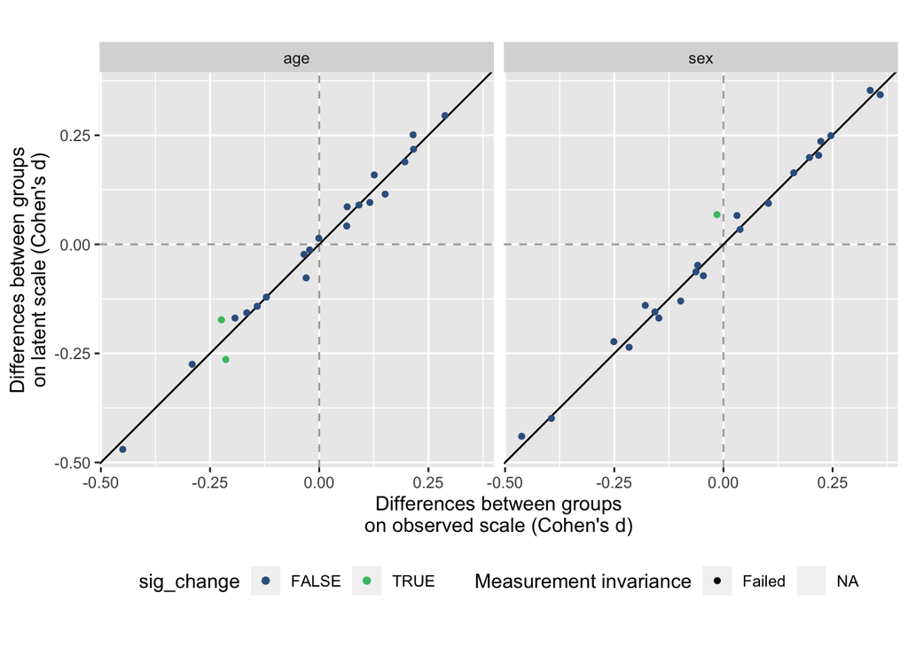

```r
# plots
ggplot(summary, aes(observed_cohens_d,
                    latent_cohens_d,
                    color = sig_change,
                    shape = `Measurement invariance`)) +
  geom_hline(yintercept = 0, linetype = "dashed", color = "darkgrey") +
  geom_vline(xintercept = 0, linetype = "dashed", color = "darkgrey") +
  geom_abline(slope = 1) +
  geom_point() +
  scale_color_viridis_d(begin = 0.3, end = 0.7) +
  xlab("Differences between groups\non observed scale (Cohen's d)") +
  ylab("Differences between groups\non latent scale (Cohen's d)") +
  coord_fixed(ratio = 1) +
  theme(legend.position = "bottom") +
  facet_wrap(~group_comparison)
```

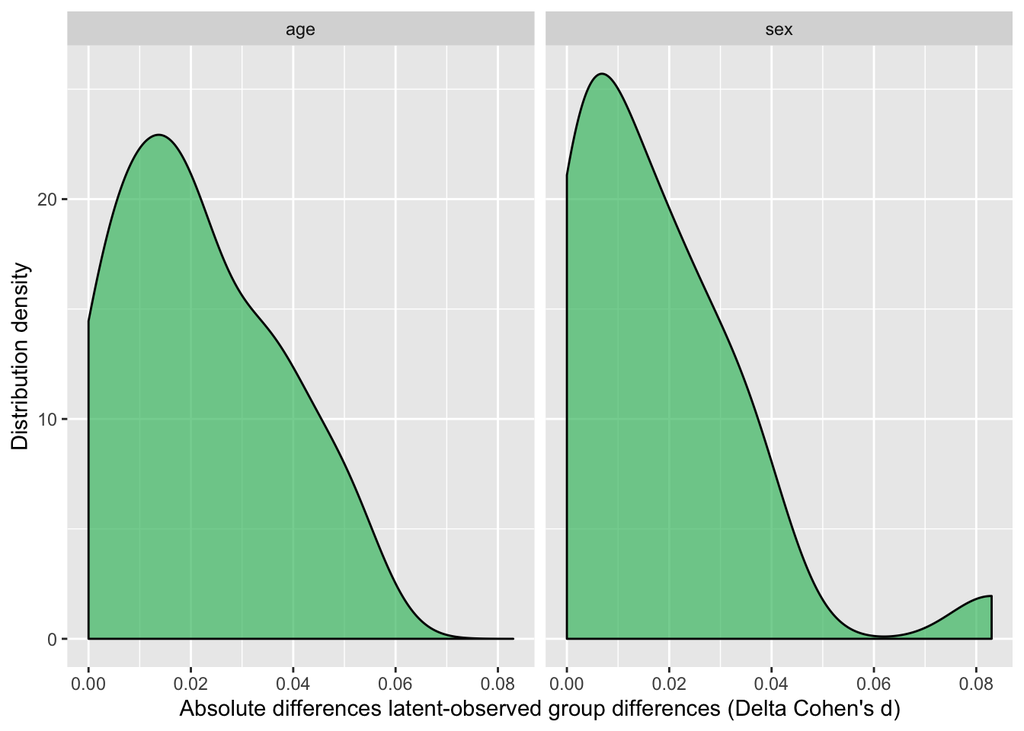

```r
ggplot(summary, aes(abs_observed_latent_cohens_d_diff, fill = "dummy")) +
  geom_density(alpha = 0.7) +
  scale_fill_viridis_d(begin = 0.7, end = 0.7) +
  theme(legend.position = "none") +
  xlab("Absolute differences latent-observed group differences (Delta Cohen's d)") +
  ylab("Distribution density") +
  facet_wrap(~group_comparison)
```

5.8% of MI tests showed a significant change in effect size between the latent and observed scores.

[^1]: Ghent University. Email: ian.hussey@ugent.be